# **Notebook 05 – CTGAN Evaluation**

Supporting materials for

## Module: DSM500 Final Project

5 October 2026

**Purpose of this notebook**  
This notebook evaluates synthetic data created by CTGAN models using four different sized minority samples. The initial results are used to select hyperparameters, then further evaluation is performed. Results from hyperparamters tuning are saved in these folders:

```
..
    |-- models
        |-- ctgan
            |-- results-b<bootstrap>
                |-- run 1
                |-- set-a
                |-- set-b
```

Full fidelity and utility evaluation results are saved here:

```
..
    |-- models
        |-- ctgan
            |-- results-b<bootstrap>
                |-- synquality-medium-ir001-b00.json
                |-- synquality-medium-ir081-b00.json
                |-- synquality-small-ir003-b00.json
                |-- synquality-small-ir009-b00.json
                |-- trtr-tstr-results.json
```

## Load the training and test sets

```python
from pprint import pprint
import pandas as pd

# Read the training set. Convert the label DataFrames back to Series
X_train = pd.read_parquet('..\\data\\processed\\X_train.parquet', engine='pyarrow')
y_train = pd.read_parquet('..\\data\\processed\\y_train.parquet', engine='pyarrow')['TARGET']
X_test = pd.read_parquet('..\\data\\processed\\X_test.parquet', engine='pyarrow')
y_test = pd.read_parquet('..\\data\\processed\\y_test.parquet', engine='pyarrow')['TARGET']

print(X_train.shape, y_train.shape, X_test.shape, y_test.shape)
```

```
(276759, 125) (276759,) (30752, 125) (30752,)
```

### Column datatypes

Create column lists by datatype for specific fidelity metrics.

```python
import json

# Group categorical, numerical, and Boolean columns for evaluation based on `dtype`
#    dtype `float` and `int` -> `numerical`
#    dtype `categorcial` -> `categorical`
#    dtype `boolean` -> `boolean`
col_details = list(X_train.dtypes.items())
numerical_cols = [col for col, dtype in col_details if dtype in ['int64', 'float64']]
categorical_cols = [col for col, dtype in col_details if dtype == 'category']
boolean_cols = [col for col, dtype in col_details if dtype == 'boolean']

print(f'{len(numerical_cols)} numerical {len(boolean_cols)} boolean {len(categorical_cols)} categorical')
```

```
70 numerical 40 boolean 15 categorical
```

## Helper functions reading real and synthetic scenario data

### Preprocessor to impute missing values (`hf_preprocess`)

```python
from sklearn.compose import ColumnTransformer
from sklearn.impute import SimpleImputer

# Create a preprocessor to replace missing with median. Only `float64` type columns have missing
# values.
float_cols = X_train.select_dtypes(include=['float64']).columns
hf_preprocess = ColumnTransformer(
    transformers=[('median_imputer', SimpleImputer(strategy='median'), float_cols)],
    remainder='passthrough',
    verbose_feature_names_out=False
).set_output(transform='pandas')
```

### Read real data for the fold or scenario (`hf_read_real_data`)

When reading real data, immediatley impute missing values. The synthetic data does not require preprocessing because it was created by a model trained on the preprocess data, therefore it will not have missing values.

```python
from pathlib import Path
import numpy as np

def hf_read_real_data(tier, ir, bootstrap):
    '''Get the training and evaluation data for a scenario.

    Summary
    -------
    Generate the path to the indices from the input parameters. Read the indices then select
    the training and test data from the full training set and return the results.
    '''
    # Get the path to the indices
    scenario = f'{tier}-ir{ir:03d}-b{bootstrap:02}'
    root = Path('..') / 'scenarios' / scenario

    # Read scenario indices and use to return a slice of the training set DataFrame
    train_file = f'training-{scenario}.txt'
    train_path = root / train_file
    train_indices = np.loadtxt(train_path, dtype=int)

    # Impute missing values
    X_train_proc = hf_preprocess.fit_transform(X_train.loc[train_indices])

    return  X_train_proc, y_train.loc[train_indices]
```

```python
# TEST
if False:
    X_train_scenario, y_train_scenario = hf_read_real_data('small', 3, 0)
    print(X_train_scenario['FLAG_OWN_CAR'].head(10))
    print(y_train_scenario.head(10))
```

### Read synthetic data (`hf_read_synthetic_data`)

This function reads a synthetic dataset for a specified level of augmentention, however for evaluation purposes only 100% augmentation is specified so that the positive-class sample size of the synthetic matches the real data.

```python
import pandas as pd, numpy as np

def hf_read_synthetic_data(tier, ir, bootstrap, aug):
    '''Get the synthetic data for an augmentation level for a scenario.

    Summary
    -------
    Generate the path to the synthetic data from the input parameters then read the data for the
    parquet file into a DataFrame.
    '''

    # Get the path to the synthetic data
    scenario = f'{tier}-ir{ir:03d}-b{bootstrap:02}'
    synthetic_file = f'synthetic-aug{aug:03}.parquet'
    root = Path('..')
    synthetic_path = root / 'scenarios' / scenario / 'synthetic' / synthetic_file

    # Read the synthetic feature data directy into a DataFrame. Since only minority data is
    # synthesised, create an array of positive labels the same length as the synthetic data.
    X_synthetic = pd.read_parquet(synthetic_path, engine='pyarrow')
    y_synthetic = pd.Series(np.ones(X_synthetic.shape[0], dtype=int), name='TARGET')

    return X_synthetic, y_synthetic
```

```python
# TEST
if False:
    X_syn_test, y_syn_test = hf_read_synthetic_data('medium', 81, 0, 100)
    print('X_syn_test:', X_syn_test.shape, 'y_syn_test:', y_syn_test.shape)
    print(X_syn_test.head(2))
    print('\n', y_syn_test.head(2))

    # Count columns with NaN
    print('NaNs...\n')
    #nans = X_syn_test.isna().sum()
    n_mono_cols = 0
    for col in X_syn_test:
        nan_count = X_syn_test[col].isna().sum()
        n_unique = X_syn_test[col].nunique()
        if n_unique == 1:
            print(col, nan_count, n_unique)
            n_mono_cols += 1

    print(n_mono_cols, 'cols with 1 value')
```

```python
# TEST
# Create a dummy snthetic data file for testing from the training set.
# Scenario: small-ir003-b00
if False:
    dummy_synthetic_data_50 = X_train.head(2793)
    dummy_synthetic_data_50.to_parquet(r"..\scenarios\small-ir003-b00\synthetic\synthetic-aug050.parquet", engine="pyarrow")
```

### Read the real and synthetic data (`hf_read_real_synthetic`)

```python
def hf_read_real_synthetic(tier, ir, bootstrap, aug=100):
    '''
    Wrapper function which calls functions to read real and synthetic data and return only the
    minority class.
    '''
    # Read the real and synthetic data. For the real data, filter on the positive class
    X_real, y_real = hf_read_real_data(tier, ir, bootstrap)
    X_real_min = X_real[y_real==1]

    # Use an augmentation level of 100% so that the synthetic sample size matches the real data
    X_syn_min, _ = hf_read_synthetic_data(tier, ir, bootstrap, 100)

    return X_real_min, X_syn_min
```

## Fidelity metrics

This section calculates different fidelity metrics for numerical, Boolean, and categorical features. Three Datatype-specific functions are called from `synthetic_data_evaluation` for a specified scenario, and the results are saved. Only the minority samples are used to train the GAN, so the IR of the scenario is irrelevant. The previously-generated synthetic data at 100% augmentation is selected to provide an equally-sized dataset to compare with the real data.

### Read a sample for testing the quality metrics

```python
# TESTING
# Read a sample for testing the functions below
if False:
    X_real, y_real = hf_read_real_data('small', 81, 0)
    X_real_min = X_real[y_real==1]
    X_syn_min, _ = hf_read_synthetic_data('small', 81, 0, 100) # Must use 100
    print('X_real_min:', X_real_min.shape, 'X_syn_min:', X_syn_min.shape)
```

### Column statistic and correlation for numerical columns (`column_stat_correlation`)

```python
import pandas as pd

def column_stat_correlation(X_real_min, X_syn_min):
    '''
    Calculate lists of distribution statistics the columns of the real and synthetic datasets,
    then calculate the correlation coefficient between the real and synthetic lists.
    '''
    assert hf_read_real_data
    assert numerical_cols is not None, f'List of numerical columns is missing'

    # Calculate the distribution statistics for all numerical columns
    numerical_real = X_real_min.loc[:,numerical_cols]
    numerical_syn = X_syn_min.loc[:,numerical_cols]
    #print(numeric_real.head(2))
    #print(numeric_syn.head(2))
    col_stats_real = pd.DataFrame({
        'mean': numerical_real.mean(),
        'std': numerical_real.std(),
        'skew': numerical_real.skew(),
        'kurt': numerical_real.kurtosis(),})
    col_stats_syn = pd.DataFrame({
        'mean': numerical_syn.mean(),
        'std': numerical_syn.std(),
        'skew': numerical_syn.skew(),
        'kurt': numerical_syn.kurtosis()})

    # Calculate and return the correlation coefficient for each statistic
    stats = ['mean', 'std', 'skew', 'kurt']
    results = {}
    for stat in stats:
        results[f'{stat}_real'] = col_stats_real[stat].to_dict()
        results[f'{stat}_syn'] = col_stats_syn[stat].to_dict()
        results[f'{stat}_corr'] = col_stats_real[stat].corr(col_stats_syn[stat]).item()

    return results
```

### Calculate similarity between Boolean columns (`boolean_probability_difference`)

```python
from scipy.spatial.distance import jensenshannon

def boolean_probability_difference(X_real_min, X_syn_min):
    '''
    Calculate the difference in the probability of positive between real and synthetic, and the
    Jensen Shannon divergence for each column, and the means. Also check for mode collapse.
    '''
    assert boolean_cols is not None, f'List of boolean columns is missing'

    # Calculate the difference in P(True) between real and syntheic for each boolean column
    boolean_real = X_real_min.loc[:,boolean_cols]
    boolean_syn = X_syn_min.loc[:,boolean_cols]
    p_true_real = boolean_real.mean()
    p_true_syn = boolean_syn.mean()
    abs_p_true_difference = (p_true_real - p_true_syn).abs()
    results = {
        'p_true_real': p_true_real.to_dict(),
        'p_true_syn': p_true_syn.to_dict(),
        'abs_diff': abs_p_true_difference.to_dict(),
        'mean_abs_diff': (abs_p_true_difference.mean()).item()}

    # Calculate the Jensen-Shannon Divergence per column and the mean. `jensenshannon` requires
    # p_false and p_true as an `nparray` so calculate these for each column
    results['jsd'] = {}
    for col in boolean_cols:
        jsd = jensenshannon(
            np.array([1 - p_true_real[col], p_true_real[col]]),
            np.array([1 - p_true_syn[col], p_true_syn[col]])
        ).item()
        results['jsd'][col] = jsd
    results['mean_jsd'] = np.mean(list(results['jsd'].values())).item()

    # Check for mode collapse. If either all positive or all negative then possible collapse. If
    # the real data include all True or all False then skip the column
    results['collapse'] = {
        col: (
            ((p_true_syn[col] == 0.0).item() and (p_true_real[col] != 0.0).item()) or
            ((p_true_syn[col] == 1.0).item() and (p_true_real[col] != 1.0).item()))
        for col in boolean_cols
    }
    return results
```

### Calculate similarity between categorical columns (`categorical_similarity`)

```python
# Check the cardinality of the categorical columns for the full training set
X_train.loc[:, categorical_cols].nunique()
```

```
CODE_GENDER                     3
NAME_TYPE_SUITE                 8
NAME_INCOME_TYPE                8
NAME_EDUCATION_TYPE             5
NAME_FAMILY_STATUS              6
NAME_HOUSING_TYPE               6
OCCUPATION_TYPE                19
REGION_RATING_CLIENT            3
REGION_RATING_CLIENT_W_CITY     3
WEEKDAY_APPR_PROCESS_START      7
ORGANIZATION_TYPE              58
FONDKAPREMONT_MODE              5
HOUSETYPE_MODE                  4
WALLSMATERIAL_MODE              8
EMERGENCYSTATE_MODE             3
dtype: int64
```

```python
def categorical_similarity(X_real_min, X_syn_min):
    '''
    Calculate similarity metrics for categorical columns to evaluate synthetic data quality.
    '''
    # Filter on categorical columns only
    categorical_real = X_real_min.loc[:, categorical_cols]
    categorical_syn = X_syn_min.loc[:, categorical_cols]

    results = {'chi_square': {}, 'chi_square_norm': {}, 'jsd': {},
               'n_categories': {}, 'missing_categories': {}, 'n_missing_categories': {},
               'missing_categories_pct': {}}

    for col in categorical_cols:

        # X-square statistic normalised by number of classes (K)
        # Get real and synthetic counts for all categories present in the real data, but not
        # necessarily present in the synthetic data
        real_all_counts = categorical_real[col].value_counts()
        real_counts = real_all_counts[real_all_counts > 0]
        syn_counts = categorical_syn[col].value_counts().reindex(
            real_counts.index, fill_value=0)
        n_cats = real_counts.shape[0]

        # Calculate the Chi-square and normalised Chi-square statistics. Include a small term in
        # the denominator so that zero oberserved count does not lead to division-by-zero
        #results['chi_square'][col] = (((expected_freq - observed_freq)**2) / observed_freq) \
        #.sum().item()
        results['chi_square'][col] = (
            ((real_counts - syn_counts)**2) / syn_counts.replace(0, 1e-6)
        ).sum().item()
        results['chi_square_norm'][col] = results['chi_square'][col] / len(real_counts)

        # Jensen-Shannon divergence (JSD)
        p = (real_counts / real_counts.sum()).replace(0, 1e-12)
        q = (syn_counts / syn_counts.sum()).replace(0, 1e-12)
        m = (0.5 * (p + q)).replace(0, 1e-12)
        jsd = 0.5*(p * np.log(p/m)).sum() + 0.5*(q * np.log(q/m)).sum()
        results['jsd'][col] = jsd.item()

        # Missing categories
        missing_categories = list(syn_counts[syn_counts == 0].index)
        results['n_categories'][col] = n_cats
        results['missing_categories'][col] = missing_categories
        results['n_missing_categories'][col] = len(missing_categories)
        results['missing_categories_pct'][col] = len(missing_categories) / n_cats * 100

    # Number of column which had missing categories
    results['n_cols_missing_categories'] = len(
        [1 for n in results['n_missing_categories'].values() if n>0])

    return results
```

```python
#TEST
if False:
    results = categorical_similarity(X_real_min, X_syn_min)
    pprint(results)
```

### Main synthetic data evaluation function (`synthetic_data_evaluation`)

```python
import json, os
from time import perf_counter

def synthetic_data_evaluation(tier, ir, bootstrap):
    '''
    Calculate and combine the evaluation metrics for numerical, Boolean, and categorical
    columns, and add the CTGAN training runtime.
    '''
    start = perf_counter()

    # Read the real and synthetic data
    X_real_min, X_syn_min = hf_read_real_synthetic(tier, ir, bootstrap)

    # Calculate the metrics based on numerical, Boolean, and categorical variables by calling
    # the helper functions
    results = {
        'tier': tier, 'ir': ir, 'bootstrap': bootstrap,
        'n_real': X_real_min.shape[0], 'n_synthetic': X_syn_min.shape[0]
    }
    results = results | column_stat_correlation(X_real_min, X_syn_min)
    results = results | boolean_probability_difference(X_real_min, X_syn_min)
    results = results | categorical_similarity(X_real_min, X_syn_min)

    # Read the training runtime from the model parameters file and add to the results
    path = '..\\models\\ctgan\\'
    filename = f'synthesizer-{tier}-ir{ir:03d}-b{bootstrap:02d}.json'
    with open(path + filename, 'r') as f:
        params = json.load(f)
    results['runtime'] = params['runtime']

    # Save the results
    path = f'..\\models\\ctgan\\results-b{bootstrap:02d}\\'
    os.makedirs(path, exist_ok=True)
    filename = f'synquality-{tier}-ir{ir:03}-b{bootstrap:02d}.json'
    print(f'Saving results to {path}{filename}')
    with open(path + filename, 'w') as f:
        json.dump(results, f, indent=2)

    return results
```

```python
# TEST
if False:
    results = synthetic_data_evaluation('small', 81, 0)
    pprint(results)
```

## Evaluate four representative synthetic datasets

To evaluate the quality of synthetic data produced by the CTGAN models, four scenarios are selected with sample sizes 545, 2,234, 5,586, and 22,342. These sizes were selected to cover the range of sample sizes with a roughly exponentially progression: x4, x2.5, x4. All fidelity metrics are calculated for each dataset.

```python
# Evaluate selected scenario
scenarios = [
    ('medium', 81, 0),    # 545 samples
    ('small', 9, 0),      # 2,234 samples
    ('small', 3, 0),      # 5,586 samples
    ('medium', 1, 0)      # 22,342 samples
]
results = []
for tier, ir, bootstrap in scenarios:
    results.append(synthetic_data_evaluation(tier, ir, bootstrap))

print('\n-- Complete --')
```

```
Saving results to ..\models\ctgan\results-b00\synquality-medium-ir081-b00.json
Saving results to ..\models\ctgan\results-b00\synquality-small-ir009-b00.json
Saving results to ..\models\ctgan\results-b00\synquality-small-ir003-b00.json
Saving results to ..\models\ctgan\results-b00\synquality-medium-ir001-b00.json

-- Complete --
```

### Tabulate evaluation results

```python
import os, json
from tabulate import tabulate

def tabulate_results(tier, ir, bootstrap):
    '''
    Present a tabulated, summarised report of the key evaluation metrics for a scenario.
    '''
    path = f'..\\models\\ctgan\\results-b{bootstrap:02d}\\'
    filename = f'synquality-{tier}-ir{ir:03d}-b{bootstrap:02}.json'
    with open(path + filename, "r") as f:
        res = json.load(f)

    # Metadata
    print("\nMETADATA\n")
    print(tabulate(
        [[res['tier'], res['ir'], res['bootstrap'], res['n_real'], res['n_synthetic'], res['runtime']]],
        headers=['Tier', 'IR', 'Bootstrap', 'N-Real', 'N-Synthetic', 'Runtime (min)'],
        floatfmt=".3f",
        tablefmt="github"
    ))
    # Numerical
    print("\nNUMERICAL METRICS\n")
    print(tabulate(
        [[res["mean_corr"], res["std_corr"], res["skew_corr"], res["kurt_corr"]]],
        headers=["Mean Corr", "Std Corr", "Skew Corr", "Kurt Corr"],
        floatfmt=".3f",
        tablefmt="github"
    ))
    # Boolean
    print('\nBOOLEAN METRICS\n')
    col_level_metrics = [ 'abs_diff', 'p_true_real', 'p_true_syn','collapse']
    boolean_headers = ['Column', '|Difference|', 'P(T)-Real', 'P(T)-Syn', 'Mode Collapse']

    cols = list(res['p_true_real'].keys())
    boolean_table = []
    for col in cols:
        row = {'col': col} | {metric: [] for metric in col_level_metrics}
        for metric in col_level_metrics:
            row[metric] = res[metric][col]
        boolean_table.append(row.values())
    print(tabulate(boolean_table, headers=boolean_headers, floatfmt='.3f', tablefmt='github'))
    collapsed_columns = [1 for collapsed in res['collapse'].values() if collapsed]
    print(f'\nColumns exhibiting mode collapse: {len(collapsed_columns)}')

    # Categorical
    print('\nCATEGORICAL METRICS\n')
    cat_headers = ['Column', 'JSD', 'Chi-Sq Norm', 'Chi-Sq', 'N Cats', 'N Missing Cats', 'Missings Cats (%)']
    cat_table = []
    cat_metrics = ['jsd', 'chi_square_norm', 'chi_square']
    for col in res['jsd'].keys():
        n_missing_cats = len(res['missing_categories'][col])
        cat_table.append([
            col,
            res['jsd'][col],
            res['chi_square_norm'][col],
            res['chi_square'][col],
            res['n_categories'][col],
            res['n_missing_categories'][col],
            res['missing_categories_pct'][col],
        ])
    print(tabulate(cat_table, headers=cat_headers, floatfmt='.3f', tablefmt='github'))

    print('\n', tabulate(
        [[res['mean_jsd'], res['n_cols_missing_categories']]],
        headers=['Mean Jensen-Shannon Divergence', 'N Columns with Missing Categories'],
        floatfmt='.3f',
        tablefmt='github'
    ), '\n', sep='')
```

### 545 samples (medium, IR 81)

```python
# Call the tabulate function
tabulate_results('medium', 81, 0)
```

```
METADATA

| Tier   |   IR |   Bootstrap |   N-Real |   N-Synthetic |   Runtime (min) |
|--------|------|-------------|----------|---------------|-----------------|
| medium |   81 |           0 |      545 |           545 |           7.393 |

NUMERICAL METRICS

|   Mean Corr |   Std Corr |   Skew Corr |   Kurt Corr |
|-------------|------------|-------------|-------------|
|       0.997 |      0.997 |       0.717 |       0.457 |

BOOLEAN METRICS

| Column                        |   |Difference| |   P(T)-Real |   P(T)-Syn | Mode Collapse   |
|-------------------------------|----------------|-------------|------------|-----------------|
| NAME_CONTRACT_TYPE            |          0.004 |       0.936 |      0.932 | False           |
| FLAG_OWN_CAR                  |          0.044 |       0.253 |      0.209 | False           |
| FLAG_OWN_REALTY               |          0.004 |       0.699 |      0.695 | False           |
| FLAG_MOBIL                    |          0.000 |       1.000 |      1.000 | False           |
| FLAG_EMP_PHONE                |          0.042 |       0.851 |      0.809 | False           |
| FLAG_WORK_PHONE               |          0.020 |       0.259 |      0.279 | False           |
| FLAG_CONT_MOBILE              |          0.007 |       0.998 |      0.991 | False           |
| FLAG_PHONE                    |          0.004 |       0.255 |      0.259 | False           |
| FLAG_EMAIL                    |          0.013 |       0.053 |      0.066 | False           |
| REG_REGION_NOT_LIVE_REGION    |          0.018 |       0.018 |      0.037 | False           |
| REG_REGION_NOT_WORK_REGION    |          0.022 |       0.062 |      0.084 | False           |
| LIVE_REGION_NOT_WORK_REGION   |          0.007 |       0.048 |      0.055 | False           |
| REG_CITY_NOT_LIVE_CITY        |          0.026 |       0.112 |      0.138 | False           |
| REG_CITY_NOT_WORK_CITY        |          0.000 |       0.319 |      0.319 | False           |
| LIVE_CITY_NOT_WORK_CITY       |          0.051 |       0.239 |      0.290 | False           |
| FLAG_DOCUMENT_2               |          0.000 |       0.000 |      0.000 | False           |
| FLAG_DOCUMENT_3               |          0.022 |       0.791 |      0.813 | False           |
| FLAG_DOCUMENT_4               |          0.000 |       0.000 |      0.000 | False           |
| FLAG_DOCUMENT_5               |          0.011 |       0.013 |      0.024 | False           |
| FLAG_DOCUMENT_6               |          0.020 |       0.068 |      0.088 | False           |
| FLAG_DOCUMENT_7               |          0.000 |       0.000 |      0.000 | False           |
| FLAG_DOCUMENT_8               |          0.024 |       0.061 |      0.084 | False           |
| FLAG_DOCUMENT_9               |          0.015 |       0.002 |      0.017 | False           |
| FLAG_DOCUMENT_10              |          0.000 |       0.000 |      0.000 | False           |
```

[output cut: 27 more lines]

```
| NAME_FAMILY_STATUS          | 0.002 |         1.747 |        8.734 |        5 |                0 |               0.000 |
| NAME_HOUSING_TYPE           | 0.002 |         0.932 |        5.593 |        6 |                0 |               0.000 |
| OCCUPATION_TYPE             | 0.006 |         2.120 |       36.042 |       17 |                0 |               0.000 |
| REGION_RATING_CLIENT        | 0.001 |         1.314 |        3.941 |        3 |                0 |               0.000 |
| REGION_RATING_CLIENT_W_CITY | 0.001 |         1.624 |        4.871 |        3 |                0 |               0.000 |
| WEEKDAY_APPR_PROCESS_START  | 0.002 |         0.918 |        6.423 |        7 |                0 |               0.000 |
| ORGANIZATION_TYPE           | 0.013 |    390244.747 | 16000034.627 |       41 |                5 |              12.195 |
| FONDKAPREMONT_MODE          | 0.001 |         0.431 |        2.153 |        5 |                0 |               0.000 |
| HOUSETYPE_MODE              | 0.001 |         1.401 |        4.202 |        3 |                0 |               0.000 |
| WALLSMATERIAL_MODE          | 0.001 |         0.663 |        5.305 |        8 |                0 |               0.000 |
| EMERGENCYSTATE_MODE         | 0.002 |         2.303 |        6.909 |        3 |                0 |               0.000 |

|   Mean Jensen-Shannon Divergence |   N Columns with Missing Categories |
|----------------------------------|-------------------------------------|
|                            0.019 |                                   1 |
```

### 2,234 samples (small, IR 9)

```python
# Call the tabulate function
tabulate_results('small', 9, 0)
```

```
METADATA

| Tier   |   IR |   Bootstrap |   N-Real |   N-Synthetic |   Runtime (min) |
|--------|------|-------------|----------|---------------|-----------------|
| small  |    9 |           0 |     2234 |          2234 |          31.520 |

NUMERICAL METRICS

|   Mean Corr |   Std Corr |   Skew Corr |   Kurt Corr |
|-------------|------------|-------------|-------------|
|       0.997 |      0.995 |       0.718 |       0.396 |

BOOLEAN METRICS

| Column                        |   |Difference| |   P(T)-Real |   P(T)-Syn | Mode Collapse   |
|-------------------------------|----------------|-------------|------------|-----------------|
| NAME_CONTRACT_TYPE            |          0.033 |       0.932 |      0.899 | False           |
| FLAG_OWN_CAR                  |          0.053 |       0.285 |      0.338 | False           |
| FLAG_OWN_REALTY               |          0.021 |       0.677 |      0.698 | False           |
| FLAG_MOBIL                    |          0.000 |       1.000 |      1.000 | False           |
| FLAG_EMP_PHONE                |          0.025 |       0.883 |      0.908 | False           |
| FLAG_WORK_PHONE               |          0.012 |       0.229 |      0.240 | False           |
| FLAG_CONT_MOBILE              |          0.005 |       0.998 |      0.993 | False           |
| FLAG_PHONE                    |          0.122 |       0.231 |      0.354 | False           |
| FLAG_EMAIL                    |          0.010 |       0.058 |      0.068 | False           |
| REG_REGION_NOT_LIVE_REGION    |          0.009 |       0.018 |      0.026 | False           |
| REG_REGION_NOT_WORK_REGION    |          0.042 |       0.056 |      0.098 | False           |
| LIVE_REGION_NOT_WORK_REGION   |          0.010 |       0.045 |      0.035 | False           |
| REG_CITY_NOT_LIVE_CITY        |          0.051 |       0.116 |      0.066 | False           |
| REG_CITY_NOT_WORK_CITY        |          0.079 |       0.298 |      0.376 | False           |
| LIVE_CITY_NOT_WORK_CITY       |          0.016 |       0.215 |      0.199 | False           |
| FLAG_DOCUMENT_2               |          0.000 |       0.000 |      0.000 | False           |
| FLAG_DOCUMENT_3               |          0.082 |       0.785 |      0.703 | False           |
| FLAG_DOCUMENT_4               |          0.000 |       0.000 |      0.000 | False           |
| FLAG_DOCUMENT_5               |          0.005 |       0.014 |      0.019 | False           |
| FLAG_DOCUMENT_6               |          0.037 |       0.055 |      0.092 | False           |
| FLAG_DOCUMENT_7               |          0.000 |       0.000 |      0.000 | False           |
| FLAG_DOCUMENT_8               |          0.026 |       0.070 |      0.096 | False           |
| FLAG_DOCUMENT_9               |          0.001 |       0.004 |      0.005 | False           |
| FLAG_DOCUMENT_10              |          0.000 |       0.000 |      0.000 | False           |
```

[output cut: 27 more lines]

```
| NAME_FAMILY_STATUS          | 0.002 |         8.063 |       40.313 |        5 |                0 |               0.000 |
| NAME_HOUSING_TYPE           | 0.001 |         3.510 |       21.061 |        6 |                0 |               0.000 |
| OCCUPATION_TYPE             | 0.005 |         4.707 |       84.732 |       18 |                0 |               0.000 |
| REGION_RATING_CLIENT        | 0.001 |         3.141 |        9.424 |        3 |                0 |               0.000 |
| REGION_RATING_CLIENT_W_CITY | 0.004 |        22.623 |       67.869 |        3 |                0 |               0.000 |
| WEEKDAY_APPR_PROCESS_START  | 0.000 |         1.288 |        9.016 |        7 |                0 |               0.000 |
| ORGANIZATION_TYPE           | 0.011 |    735852.322 | 39000173.066 |       53 |                6 |              11.321 |
| FONDKAPREMONT_MODE          | 0.003 |         9.069 |       45.346 |        5 |                0 |               0.000 |
| HOUSETYPE_MODE              | 0.003 |        14.372 |       57.489 |        4 |                0 |               0.000 |
| WALLSMATERIAL_MODE          | 0.002 |         3.594 |       28.755 |        8 |                0 |               0.000 |
| EMERGENCYSTATE_MODE         | 0.002 |        11.237 |       33.712 |        3 |                0 |               0.000 |

|   Mean Jensen-Shannon Divergence |   N Columns with Missing Categories |
|----------------------------------|-------------------------------------|
|                            0.029 |                                   1 |
```

### 5,586 samples (small, IR 3)

```python
# Call the tabulate function
tabulate_results('small', 3, 0)
```

```
METADATA

| Tier   |   IR |   Bootstrap |   N-Real |   N-Synthetic |   Runtime (min) |
|--------|------|-------------|----------|---------------|-----------------|
| small  |    3 |           0 |     5586 |          5586 |          73.080 |

NUMERICAL METRICS

|   Mean Corr |   Std Corr |   Skew Corr |   Kurt Corr |
|-------------|------------|-------------|-------------|
|       0.999 |      0.996 |       0.763 |       0.468 |

BOOLEAN METRICS

| Column                        |   |Difference| |   P(T)-Real |   P(T)-Syn | Mode Collapse   |
|-------------------------------|----------------|-------------|------------|-----------------|
| NAME_CONTRACT_TYPE            |          0.057 |       0.939 |      0.882 | False           |
| FLAG_OWN_CAR                  |          0.092 |       0.313 |      0.221 | False           |
| FLAG_OWN_REALTY               |          0.122 |       0.685 |      0.807 | False           |
| FLAG_MOBIL                    |          0.000 |       1.000 |      1.000 | False           |
| FLAG_EMP_PHONE                |          0.052 |       0.878 |      0.930 | False           |
| FLAG_WORK_PHONE               |          0.127 |       0.245 |      0.373 | False           |
| FLAG_CONT_MOBILE              |          0.003 |       0.998 |      0.995 | False           |
| FLAG_PHONE                    |          0.065 |       0.242 |      0.177 | False           |
| FLAG_EMAIL                    |          0.030 |       0.059 |      0.089 | False           |
| REG_REGION_NOT_LIVE_REGION    |          0.013 |       0.018 |      0.031 | False           |
| REG_REGION_NOT_WORK_REGION    |          0.053 |       0.065 |      0.118 | False           |
| LIVE_REGION_NOT_WORK_REGION   |          0.013 |       0.051 |      0.064 | False           |
| REG_CITY_NOT_LIVE_CITY        |          0.024 |       0.119 |      0.095 | False           |
| REG_CITY_NOT_WORK_CITY        |          0.025 |       0.302 |      0.277 | False           |
| LIVE_CITY_NOT_WORK_CITY       |          0.014 |       0.224 |      0.238 | False           |
| FLAG_DOCUMENT_2               |          0.002 |       0.000 |      0.002 | False           |
| FLAG_DOCUMENT_3               |          0.119 |       0.774 |      0.655 | False           |
| FLAG_DOCUMENT_4               |          0.000 |       0.000 |      0.000 | False           |
| FLAG_DOCUMENT_5               |          0.010 |       0.015 |      0.025 | False           |
| FLAG_DOCUMENT_6               |          0.021 |       0.064 |      0.085 | False           |
| FLAG_DOCUMENT_7               |          0.000 |       0.000 |      0.000 | False           |
| FLAG_DOCUMENT_8               |          0.043 |       0.077 |      0.120 | False           |
| FLAG_DOCUMENT_9               |          0.002 |       0.003 |      0.005 | False           |
| FLAG_DOCUMENT_10              |          0.000 |       0.000 |      0.000 | False           |
```

[output cut: 27 more lines]

```
| NAME_FAMILY_STATUS          | 0.001 |        10.398 |       51.992 |        5 |                0 |               0.000 |
| NAME_HOUSING_TYPE           | 0.000 |         2.188 |       13.127 |        6 |                0 |               0.000 |
| OCCUPATION_TYPE             | 0.004 |         7.961 |      151.258 |       19 |                0 |               0.000 |
| REGION_RATING_CLIENT        | 0.001 |         8.865 |       26.595 |        3 |                0 |               0.000 |
| REGION_RATING_CLIENT_W_CITY | 0.001 |         9.531 |       28.593 |        3 |                0 |               0.000 |
| WEEKDAY_APPR_PROCESS_START  | 0.006 |        35.821 |      250.746 |        7 |                0 |               0.000 |
| ORGANIZATION_TYPE           | 0.006 |    719302.806 | 41000259.963 |       57 |                7 |              12.281 |
| FONDKAPREMONT_MODE          | 0.001 |         8.425 |       42.124 |        5 |                0 |               0.000 |
| HOUSETYPE_MODE              | 0.000 |         3.617 |       14.469 |        4 |                0 |               0.000 |
| WALLSMATERIAL_MODE          | 0.001 |         4.832 |       38.652 |        8 |                0 |               0.000 |
| EMERGENCYSTATE_MODE         | 0.000 |         1.816 |        5.448 |        3 |                0 |               0.000 |

|   Mean Jensen-Shannon Divergence |   N Columns with Missing Categories |
|----------------------------------|-------------------------------------|
|                            0.031 |                                   1 |
```

### 22,342 samples (medium, IR 1)

```python
# Call the tabulate function
tabulate_results('medium', 1, 0)
```

```
METADATA

| Tier   |   IR |   Bootstrap |   N-Real |   N-Synthetic |   Runtime (min) |
|--------|------|-------------|----------|---------------|-----------------|
| medium |    1 |           0 |    22342 |         22342 |         265.560 |

NUMERICAL METRICS

|   Mean Corr |   Std Corr |   Skew Corr |   Kurt Corr |
|-------------|------------|-------------|-------------|
|       0.998 |      0.671 |       0.305 |       0.005 |

BOOLEAN METRICS

| Column                        |   |Difference| |   P(T)-Real |   P(T)-Syn | Mode Collapse   |
|-------------------------------|----------------|-------------|------------|-----------------|
| NAME_CONTRACT_TYPE            |          0.010 |       0.935 |      0.946 | False           |
| FLAG_OWN_CAR                  |          0.003 |       0.304 |      0.302 | False           |
| FLAG_OWN_REALTY               |          0.033 |       0.684 |      0.651 | False           |
| FLAG_MOBIL                    |          0.000 |       1.000 |      1.000 | False           |
| FLAG_EMP_PHONE                |          0.005 |       0.880 |      0.875 | False           |
| FLAG_WORK_PHONE               |          0.239 |       0.239 |      0.478 | False           |
| FLAG_CONT_MOBILE              |          0.006 |       0.998 |      0.992 | False           |
| FLAG_PHONE                    |          0.016 |       0.246 |      0.262 | False           |
| FLAG_EMAIL                    |          0.004 |       0.056 |      0.061 | False           |
| REG_REGION_NOT_LIVE_REGION    |          0.012 |       0.017 |      0.030 | False           |
| REG_REGION_NOT_WORK_REGION    |          0.023 |       0.056 |      0.079 | False           |
| LIVE_REGION_NOT_WORK_REGION   |          0.046 |       0.043 |      0.089 | False           |
| REG_CITY_NOT_LIVE_CITY        |          0.067 |       0.119 |      0.186 | False           |
| REG_CITY_NOT_WORK_CITY        |          0.007 |       0.303 |      0.310 | False           |
| LIVE_CITY_NOT_WORK_CITY       |          0.006 |       0.221 |      0.227 | False           |
| FLAG_DOCUMENT_2               |          0.003 |       0.000 |      0.004 | False           |
| FLAG_DOCUMENT_3               |          0.051 |       0.778 |      0.727 | False           |
| FLAG_DOCUMENT_4               |          0.000 |       0.000 |      0.000 | False           |
| FLAG_DOCUMENT_5               |          0.009 |       0.015 |      0.025 | False           |
| FLAG_DOCUMENT_6               |          0.006 |       0.061 |      0.055 | False           |
| FLAG_DOCUMENT_7               |          0.003 |       0.000 |      0.003 | False           |
| FLAG_DOCUMENT_8               |          0.023 |       0.073 |      0.051 | False           |
| FLAG_DOCUMENT_9               |          0.006 |       0.003 |      0.009 | False           |
| FLAG_DOCUMENT_10              |          0.000 |       0.000 |      0.000 | False           |
```

[output cut: 27 more lines]

```
| NAME_FAMILY_STATUS          | 0.003 |       119.783 |  598.917 |        5 |                0 |               0.000 |
| NAME_HOUSING_TYPE           | 0.012 |       281.119 | 1686.711 |        6 |                0 |               0.000 |
| OCCUPATION_TYPE             | 0.007 |        61.740 | 1173.062 |       19 |                0 |               0.000 |
| REGION_RATING_CLIENT        | 0.002 |        95.738 |  287.214 |        3 |                0 |               0.000 |
| REGION_RATING_CLIENT_W_CITY | 0.002 |       116.394 |  349.183 |        3 |                0 |               0.000 |
| WEEKDAY_APPR_PROCESS_START  | 0.008 |       216.220 | 1513.543 |        7 |                0 |               0.000 |
| ORGANIZATION_TYPE           | 0.003 |        10.394 |  602.863 |       58 |                0 |               0.000 |
| FONDKAPREMONT_MODE          | 0.002 |        57.546 |  287.731 |        5 |                0 |               0.000 |
| HOUSETYPE_MODE              | 0.001 |        44.515 |  178.059 |        4 |                0 |               0.000 |
| WALLSMATERIAL_MODE          | 0.001 |        28.576 |  228.609 |        8 |                0 |               0.000 |
| EMERGENCYSTATE_MODE         | 0.001 |        49.902 |  149.706 |        3 |                0 |               0.000 |

|   Mean Jensen-Shannon Divergence |   N Columns with Missing Categories |
|----------------------------------|-------------------------------------|
|                            0.028 |                                   0 |
```

## Hyperparameter tuning results

### Set A (Final Selection)

```
{
    "enforce_min_max_values": true,
    "enforce_rounding": true,
    "locales": [
        "en_US"
    ],
    "embedding_dim": 64,
    "generator_dim": [
        128,
        128
    ],
    "discriminator_dim": [
        128,
        128
    ],
    "generator_lr": 0.0001,
    "generator_decay": 1e-06,
    "discriminator_lr": 0.0003,
    "discriminator_decay": 1e-06,
    "batch_size": 120,
    "discriminator_steps": 1,
    "log_frequency": true,
    "verbose": true,
    "epochs": 400,
    "pac": 10,
    "enable_gpu": true,
    "runtime": 265.5596656866663,
    "n_samples": 22342
}
```

```
SET A
=====

METADATA

| Tier   |   IR |   Bootstrap |   N-Real |   N-Synthetic |   Runtime (min) |
|--------|------|-------------|----------|---------------|-----------------|
| medium |   81 |           0 |      545 |           545 |           7.393 |

NUMERICAL METRICS

|   Mean Corr |   Std Corr |   Skew Corr |   Kurt Corr |
|-------------|------------|-------------|-------------|
|       0.997 |      0.997 |       0.605 |       0.256 |

BOOLEAN METRICS

| Column                        |   |Difference| |   P(T)-Real |   P(T)-Syn | Mode Collapse   |
|-------------------------------|----------------|-------------|------------|-----------------|
| NAME_CONTRACT_TYPE            |          0.004 |       0.936 |      0.932 | False           |
| FLAG_OWN_CAR                  |          0.044 |       0.253 |      0.209 | False           |
| FLAG_OWN_REALTY               |          0.004 |       0.699 |      0.695 | False           |
| FLAG_MOBIL                    |          0.000 |       1.000 |      1.000 | False           |
| FLAG_EMP_PHONE                |          0.042 |       0.851 |      0.809 | False           |
| FLAG_WORK_PHONE               |          0.020 |       0.259 |      0.279 | False           |
| FLAG_CONT_MOBILE              |          0.007 |       0.998 |      0.991 | False           |
| FLAG_PHONE                    |          0.004 |       0.255 |      0.259 | False           |
| FLAG_EMAIL                    |          0.013 |       0.053 |      0.066 | False           |
| REG_REGION_NOT_LIVE_REGION    |          0.018 |       0.018 |      0.037 | False           |
| REG_REGION_NOT_WORK_REGION    |          0.022 |       0.062 |      0.084 | False           |
| LIVE_REGION_NOT_WORK_REGION   |          0.007 |       0.048 |      0.055 | False           |
| REG_CITY_NOT_LIVE_CITY        |          0.026 |       0.112 |      0.138 | False           |
| REG_CITY_NOT_WORK_CITY        |          0.000 |       0.319 |      0.319 | False           |
| LIVE_CITY_NOT_WORK_CITY       |          0.051 |       0.239 |      0.290 | False           |
| FLAG_DOCUMENT_2               |          0.000 |       0.000 |      0.000 | False           |
| FLAG_DOCUMENT_3               |          0.022 |       0.791 |      0.813 | False           |
| FLAG_DOCUMENT_4               |          0.000 |       0.000 |      0.000 | False           |
| FLAG_DOCUMENT_5               |          0.011 |       0.013 |      0.024 | False           |
| FLAG_DOCUMENT_6               |          0.020 |       0.068 |      0.088 | False           |
| FLAG_DOCUMENT_7               |          0.000 |       0.000 |      0.000 | False           |
| FLAG_DOCUMENT_8               |          0.024 |       0.061 |      0.084 | False           |
| FLAG_DOCUMENT_9               |          0.015 |       0.002 |      0.017 | False           |
| FLAG_DOCUMENT_10              |          0.000 |       0.000 |      0.000 | False           |
| FLAG_DOCUMENT_11              |          0.013 |       0.002 |      0.015 | False           |
| FLAG_DOCUMENT_12              |          0.000 |       0.000 |      0.000 | False           |
| FLAG_DOCUMENT_13              |          0.000 |       0.000 |      0.000 | False           |
| FLAG_DOCUMENT_14              |          0.007 |       0.002 |      0.009 | False           |
| FLAG_DOCUMENT_15              |          0.000 |       0.000 |      0.000 | False           |
| FLAG_DOCUMENT_16              |          0.009 |       0.009 |      0.018 | False           |
| FLAG_DOCUMENT_17              |          0.000 |       0.000 |      0.000 | False           |
| FLAG_DOCUMENT_18              |          0.009 |       0.009 |      0.018 | False           |
| FLAG_DOCUMENT_19              |          0.000 |       0.000 |      0.000 | False           |
| FLAG_DOCUMENT_20              |          0.000 |       0.000 |      0.000 | False           |
| FLAG_DOCUMENT_21              |          0.000 |       0.000 |      0.000 | False           |
| AMT_REQ_CREDIT_BUREAU_MISSING |          0.037 |       0.198 |      0.235 | False           |
| EXT_SOURCE_1_MISSING          |          0.035 |       0.607 |      0.572 | False           |
| EXT_SOURCE_3_MISSING          |          0.013 |       0.244 |      0.231 | False           |
| OWN_CAR_AGE_MISSING           |          0.062 |       0.747 |      0.809 | False           |
| STATS_MISSING                 |          0.017 |       0.609 |      0.626 | False           |

Columns exhibiting mode collapse: 0

CATEGORICAL METRICS

| Column                      |   JSD |   Chi-Sq Norm |       Chi-Sq |   N Cats |   N Missing Cats |   Missings Cats (%) |
|-----------------------------|-------|---------------|--------------|----------|------------------|---------------------|
| CODE_GENDER                 | 0.002 |         3.828 |        7.657 |        2 |                0 |               0.000 |
| NAME_TYPE_SUITE             | 0.000 |         0.288 |        1.730 |        6 |                0 |               0.000 |
| NAME_INCOME_TYPE            | 0.001 |         1.369 |        5.477 |        4 |                0 |               0.000 |
| NAME_EDUCATION_TYPE         | 0.003 |         2.834 |       11.336 |        4 |                0 |               0.000 |
| NAME_FAMILY_STATUS          | 0.002 |         1.747 |        8.734 |        5 |                0 |               0.000 |
| NAME_HOUSING_TYPE           | 0.002 |         0.932 |        5.593 |        6 |                0 |               0.000 |
| OCCUPATION_TYPE             | 0.006 |         2.120 |       36.042 |       17 |                0 |               0.000 |
| REGION_RATING_CLIENT        | 0.001 |         1.314 |        3.941 |        3 |                0 |               0.000 |
| REGION_RATING_CLIENT_W_CITY | 0.001 |         1.624 |        4.871 |        3 |                0 |               0.000 |
| WEEKDAY_APPR_PROCESS_START  | 0.002 |         0.918 |        6.423 |        7 |                0 |               0.000 |
| ORGANIZATION_TYPE           | 0.013 |    390244.747 | 16000034.627 |       41 |                5 |              12.195 |
| FONDKAPREMONT_MODE          | 0.001 |         0.431 |        2.153 |        5 |                0 |               0.000 |
| HOUSETYPE_MODE              | 0.001 |         1.401 |        4.202 |        3 |                0 |               0.000 |
| WALLSMATERIAL_MODE          | 0.001 |         0.663 |        5.305 |        8 |                0 |               0.000 |
| EMERGENCYSTATE_MODE         | 0.002 |         2.303 |        6.909 |        3 |                0 |               0.000 |
```

```
|   Mean Jensen-Shannon Divergence |   N Columns with Missing Categories |
|----------------------------------|-------------------------------------|
|                            0.019 |                                   1 |

========================================================================================================================


METADATA

| Tier   |   IR |   Bootstrap |   N-Real |   N-Synthetic |   Runtime (min) |
|--------|------|-------------|----------|---------------|-----------------|
| small  |    9 |           0 |     2234 |          2234 |          31.520 |

NUMERICAL METRICS

|   Mean Corr |   Std Corr |   Skew Corr |   Kurt Corr |
|-------------|------------|-------------|-------------|
|       0.997 |      0.995 |       0.738 |       0.543 |

BOOLEAN METRICS

| Column                        |   |Difference| |   P(T)-Real |   P(T)-Syn | Mode Collapse   |
|-------------------------------|----------------|-------------|------------|-----------------|
| NAME_CONTRACT_TYPE            |          0.033 |       0.932 |      0.899 | False           |
| FLAG_OWN_CAR                  |          0.053 |       0.285 |      0.338 | False           |
| FLAG_OWN_REALTY               |          0.021 |       0.677 |      0.698 | False           |
| FLAG_MOBIL                    |          0.000 |       1.000 |      1.000 | False           |
| FLAG_EMP_PHONE                |          0.025 |       0.883 |      0.908 | False           |
| FLAG_WORK_PHONE               |          0.012 |       0.229 |      0.240 | False           |
| FLAG_CONT_MOBILE              |          0.005 |       0.998 |      0.993 | False           |
| FLAG_PHONE                    |          0.122 |       0.231 |      0.354 | False           |
| FLAG_EMAIL                    |          0.010 |       0.058 |      0.068 | False           |
| REG_REGION_NOT_LIVE_REGION    |          0.009 |       0.018 |      0.026 | False           |
| REG_REGION_NOT_WORK_REGION    |          0.042 |       0.056 |      0.098 | False           |
| LIVE_REGION_NOT_WORK_REGION   |          0.010 |       0.045 |      0.035 | False           |
| REG_CITY_NOT_LIVE_CITY        |          0.051 |       0.116 |      0.066 | False           |
| REG_CITY_NOT_WORK_CITY        |          0.079 |       0.298 |      0.376 | False           |
| LIVE_CITY_NOT_WORK_CITY       |          0.016 |       0.215 |      0.199 | False           |
| FLAG_DOCUMENT_2               |          0.000 |       0.000 |      0.000 | False           |
| FLAG_DOCUMENT_3               |          0.082 |       0.785 |      0.703 | False           |
| FLAG_DOCUMENT_4               |          0.000 |       0.000 |      0.000 | False           |
| FLAG_DOCUMENT_5               |          0.005 |       0.014 |      0.019 | False           |
| FLAG_DOCUMENT_6               |          0.037 |       0.055 |      0.092 | False           |
| FLAG_DOCUMENT_7               |          0.000 |       0.000 |      0.000 | False           |
| FLAG_DOCUMENT_8               |          0.026 |       0.070 |      0.096 | False           |
| FLAG_DOCUMENT_9               |          0.001 |       0.004 |      0.005 | False           |
| FLAG_DOCUMENT_10              |          0.000 |       0.000 |      0.000 | False           |
| FLAG_DOCUMENT_11              |          0.003 |       0.002 |      0.005 | False           |
| FLAG_DOCUMENT_12              |          0.000 |       0.000 |      0.000 | False           |
| FLAG_DOCUMENT_13              |          0.000 |       0.000 |      0.000 | False           |
| FLAG_DOCUMENT_14              |          0.003 |       0.000 |      0.003 | False           |
| FLAG_DOCUMENT_15              |          0.003 |       0.000 |      0.003 | False           |
| FLAG_DOCUMENT_16              |          0.016 |       0.010 |      0.026 | False           |
| FLAG_DOCUMENT_17              |          0.000 |       0.000 |      0.000 | False           |
| FLAG_DOCUMENT_18              |          0.005 |       0.005 |      0.010 | False           |
| FLAG_DOCUMENT_19              |          0.005 |       0.000 |      0.005 | False           |
| FLAG_DOCUMENT_20              |          0.003 |       0.000 |      0.003 | False           |
| FLAG_DOCUMENT_21              |          0.006 |       0.002 |      0.008 | False           |
| AMT_REQ_CREDIT_BUREAU_MISSING |          0.018 |       0.179 |      0.161 | False           |
| EXT_SOURCE_1_MISSING          |          0.053 |       0.590 |      0.643 | False           |
| EXT_SOURCE_3_MISSING          |          0.099 |       0.231 |      0.131 | False           |
| OWN_CAR_AGE_MISSING           |          0.130 |       0.715 |      0.585 | False           |
| STATS_MISSING                 |          0.052 |       0.604 |      0.552 | False           |

Columns exhibiting mode collapse: 0

CATEGORICAL METRICS

| Column                      |   JSD |   Chi-Sq Norm |       Chi-Sq |   N Cats |   N Missing Cats |   Missings Cats (%) |
|-----------------------------|-------|---------------|--------------|----------|------------------|---------------------|
| CODE_GENDER                 | 0.002 |        17.006 |       34.013 |        2 |                0 |               0.000 |
| NAME_TYPE_SUITE             | 0.006 |        10.751 |       86.010 |        8 |                0 |               0.000 |
| NAME_INCOME_TYPE            | 0.002 |        10.240 |       40.959 |        4 |                0 |               0.000 |
| NAME_EDUCATION_TYPE         | 0.001 |         4.047 |       16.186 |        4 |                0 |               0.000 |
| NAME_FAMILY_STATUS          | 0.002 |         8.063 |       40.313 |        5 |                0 |               0.000 |
| NAME_HOUSING_TYPE           | 0.001 |         3.510 |       21.061 |        6 |                0 |               0.000 |
| OCCUPATION_TYPE             | 0.005 |         4.707 |       84.732 |       18 |                0 |               0.000 |
| REGION_RATING_CLIENT        | 0.001 |         3.141 |        9.424 |        3 |                0 |               0.000 |
| REGION_RATING_CLIENT_W_CITY | 0.004 |        22.623 |       67.869 |        3 |                0 |               0.000 |
| WEEKDAY_APPR_PROCESS_START  | 0.000 |         1.288 |        9.016 |        7 |                0 |               0.000 |
| ORGANIZATION_TYPE           | 0.011 |    735852.322 | 39000173.066 |       53 |                6 |              11.321 |
| FONDKAPREMONT_MODE          | 0.003 |         9.069 |       45.346 |        5 |                0 |               0.000 |
| HOUSETYPE_MODE              | 0.003 |        14.372 |       57.489 |        4 |                0 |               0.000 |
| WALLSMATERIAL_MODE          | 0.002 |         3.594 |       28.755 |        8 |                0 |               0.000 |
| EMERGENCYSTATE_MODE         | 0.002 |        11.237 |       33.712 |        3 |                0 |               0.000 |
```

```
|   Mean Jensen-Shannon Divergence |   N Columns with Missing Categories |
|----------------------------------|-------------------------------------|
|                            0.029 |                                   1 |

========================================================================================================================


METADATA

| Tier   |   IR |   Bootstrap |   N-Real |   N-Synthetic |   Runtime (min) |
|--------|------|-------------|----------|---------------|-----------------|
| small  |    3 |           0 |     5586 |          5586 |          73.080 |

NUMERICAL METRICS

|   Mean Corr |   Std Corr |   Skew Corr |   Kurt Corr |
|-------------|------------|-------------|-------------|
|       0.999 |      0.996 |       0.813 |       0.672 |

BOOLEAN METRICS

| Column                        |   |Difference| |   P(T)-Real |   P(T)-Syn | Mode Collapse   |
|-------------------------------|----------------|-------------|------------|-----------------|
| NAME_CONTRACT_TYPE            |          0.057 |       0.939 |      0.882 | False           |
| FLAG_OWN_CAR                  |          0.092 |       0.313 |      0.221 | False           |
| FLAG_OWN_REALTY               |          0.122 |       0.685 |      0.807 | False           |
| FLAG_MOBIL                    |          0.000 |       1.000 |      1.000 | False           |
| FLAG_EMP_PHONE                |          0.052 |       0.878 |      0.930 | False           |
| FLAG_WORK_PHONE               |          0.127 |       0.245 |      0.373 | False           |
| FLAG_CONT_MOBILE              |          0.003 |       0.998 |      0.995 | False           |
| FLAG_PHONE                    |          0.065 |       0.242 |      0.177 | False           |
| FLAG_EMAIL                    |          0.030 |       0.059 |      0.089 | False           |
| REG_REGION_NOT_LIVE_REGION    |          0.013 |       0.018 |      0.031 | False           |
| REG_REGION_NOT_WORK_REGION    |          0.053 |       0.065 |      0.118 | False           |
| LIVE_REGION_NOT_WORK_REGION   |          0.013 |       0.051 |      0.064 | False           |
| REG_CITY_NOT_LIVE_CITY        |          0.024 |       0.119 |      0.095 | False           |
| REG_CITY_NOT_WORK_CITY        |          0.025 |       0.302 |      0.277 | False           |
| LIVE_CITY_NOT_WORK_CITY       |          0.014 |       0.224 |      0.238 | False           |
| FLAG_DOCUMENT_2               |          0.002 |       0.000 |      0.002 | False           |
| FLAG_DOCUMENT_3               |          0.119 |       0.774 |      0.655 | False           |
| FLAG_DOCUMENT_4               |          0.000 |       0.000 |      0.000 | False           |
| FLAG_DOCUMENT_5               |          0.010 |       0.015 |      0.025 | False           |
| FLAG_DOCUMENT_6               |          0.021 |       0.064 |      0.085 | False           |
| FLAG_DOCUMENT_7               |          0.000 |       0.000 |      0.000 | False           |
| FLAG_DOCUMENT_8               |          0.043 |       0.077 |      0.120 | False           |
| FLAG_DOCUMENT_9               |          0.002 |       0.003 |      0.005 | False           |
| FLAG_DOCUMENT_10              |          0.000 |       0.000 |      0.000 | False           |
| FLAG_DOCUMENT_11              |          0.005 |       0.004 |      0.009 | False           |
| FLAG_DOCUMENT_12              |          0.000 |       0.000 |      0.000 | False           |
| FLAG_DOCUMENT_13              |          0.003 |       0.001 |      0.004 | False           |
| FLAG_DOCUMENT_14              |          0.003 |       0.001 |      0.004 | False           |
| FLAG_DOCUMENT_15              |          0.000 |       0.000 |      0.000 | False           |
| FLAG_DOCUMENT_16              |          0.006 |       0.005 |      0.011 | False           |
| FLAG_DOCUMENT_17              |          0.000 |       0.000 |      0.000 | False           |
| FLAG_DOCUMENT_18              |          0.010 |       0.006 |      0.016 | False           |
| FLAG_DOCUMENT_19              |          0.002 |       0.000 |      0.002 | False           |
| FLAG_DOCUMENT_20              |          0.002 |       0.000 |      0.002 | False           |
| FLAG_DOCUMENT_21              |          0.002 |       0.001 |      0.003 | False           |
| AMT_REQ_CREDIT_BUREAU_MISSING |          0.003 |       0.172 |      0.169 | False           |
| EXT_SOURCE_1_MISSING          |          0.066 |       0.593 |      0.528 | False           |
| EXT_SOURCE_3_MISSING          |          0.022 |       0.228 |      0.206 | False           |
| OWN_CAR_AGE_MISSING           |          0.078 |       0.687 |      0.764 | False           |
| STATS_MISSING                 |          0.013 |       0.591 |      0.579 | False           |

Columns exhibiting mode collapse: 0

CATEGORICAL METRICS

| Column                      |   JSD |   Chi-Sq Norm |       Chi-Sq |   N Cats |   N Missing Cats |   Missings Cats (%) |
|-----------------------------|-------|---------------|--------------|----------|------------------|---------------------|
| CODE_GENDER                 | 0.006 |       136.077 |      272.154 |        2 |                0 |               0.000 |
| NAME_TYPE_SUITE             | 0.003 |        22.343 |      178.740 |        8 |                0 |               0.000 |
| NAME_INCOME_TYPE            | 0.004 |        32.600 |      195.601 |        6 |                0 |               0.000 |
| NAME_EDUCATION_TYPE         | 0.000 |         1.170 |        5.852 |        5 |                0 |               0.000 |
| NAME_FAMILY_STATUS          | 0.001 |        10.398 |       51.992 |        5 |                0 |               0.000 |
| NAME_HOUSING_TYPE           | 0.000 |         2.188 |       13.127 |        6 |                0 |               0.000 |
| OCCUPATION_TYPE             | 0.004 |         7.961 |      151.258 |       19 |                0 |               0.000 |
| REGION_RATING_CLIENT        | 0.001 |         8.865 |       26.595 |        3 |                0 |               0.000 |
| REGION_RATING_CLIENT_W_CITY | 0.001 |         9.531 |       28.593 |        3 |                0 |               0.000 |
| WEEKDAY_APPR_PROCESS_START  | 0.006 |        35.821 |      250.746 |        7 |                0 |               0.000 |
| ORGANIZATION_TYPE           | 0.006 |    719302.806 | 41000259.963 |       57 |                7 |              12.281 |
| FONDKAPREMONT_MODE          | 0.001 |         8.425 |       42.124 |        5 |                0 |               0.000 |
| HOUSETYPE_MODE              | 0.000 |         3.617 |       14.469 |        4 |                0 |               0.000 |
| WALLSMATERIAL_MODE          | 0.001 |         4.832 |       38.652 |        8 |                0 |               0.000 |
| EMERGENCYSTATE_MODE         | 0.000 |         1.816 |        5.448 |        3 |                0 |               0.000 |
```

```
|   Mean Jensen-Shannon Divergence |   N Columns with Missing Categories |
|----------------------------------|-------------------------------------|
|                            0.031 |                                   1 |

========================================================================================================================


METADATA

| Tier   |   IR |   Bootstrap |   N-Real |   N-Synthetic |   Runtime (min) |
|--------|------|-------------|----------|---------------|-----------------|
| medium |    1 |           0 |    22342 |         22342 |         265.560 |

NUMERICAL METRICS

|   Mean Corr |   Std Corr |   Skew Corr |   Kurt Corr |
|-------------|------------|-------------|-------------|
|       0.998 |      0.672 |       0.176 |      -0.027 |

BOOLEAN METRICS

| Column                        |   |Difference| |   P(T)-Real |   P(T)-Syn | Mode Collapse   |
|-------------------------------|----------------|-------------|------------|-----------------|
| NAME_CONTRACT_TYPE            |          0.010 |       0.935 |      0.946 | False           |
| FLAG_OWN_CAR                  |          0.003 |       0.304 |      0.302 | False           |
| FLAG_OWN_REALTY               |          0.033 |       0.684 |      0.651 | False           |
| FLAG_MOBIL                    |          0.000 |       1.000 |      1.000 | False           |
| FLAG_EMP_PHONE                |          0.005 |       0.880 |      0.875 | False           |
| FLAG_WORK_PHONE               |          0.239 |       0.239 |      0.478 | False           |
| FLAG_CONT_MOBILE              |          0.006 |       0.998 |      0.992 | False           |
| FLAG_PHONE                    |          0.016 |       0.246 |      0.262 | False           |
| FLAG_EMAIL                    |          0.004 |       0.056 |      0.061 | False           |
| REG_REGION_NOT_LIVE_REGION    |          0.012 |       0.017 |      0.030 | False           |
| REG_REGION_NOT_WORK_REGION    |          0.023 |       0.056 |      0.079 | False           |
| LIVE_REGION_NOT_WORK_REGION   |          0.046 |       0.043 |      0.089 | False           |
| REG_CITY_NOT_LIVE_CITY        |          0.067 |       0.119 |      0.186 | False           |
| REG_CITY_NOT_WORK_CITY        |          0.007 |       0.303 |      0.310 | False           |
| LIVE_CITY_NOT_WORK_CITY       |          0.006 |       0.221 |      0.227 | False           |
| FLAG_DOCUMENT_2               |          0.003 |       0.000 |      0.004 | False           |
| FLAG_DOCUMENT_3               |          0.051 |       0.778 |      0.727 | False           |
| FLAG_DOCUMENT_4               |          0.000 |       0.000 |      0.000 | False           |
| FLAG_DOCUMENT_5               |          0.009 |       0.015 |      0.025 | False           |
| FLAG_DOCUMENT_6               |          0.006 |       0.061 |      0.055 | False           |
| FLAG_DOCUMENT_7               |          0.003 |       0.000 |      0.003 | False           |
| FLAG_DOCUMENT_8               |          0.023 |       0.073 |      0.051 | False           |
| FLAG_DOCUMENT_9               |          0.006 |       0.003 |      0.009 | False           |
| FLAG_DOCUMENT_10              |          0.000 |       0.000 |      0.000 | False           |
| FLAG_DOCUMENT_11              |          0.005 |       0.003 |      0.007 | False           |
| FLAG_DOCUMENT_12              |          0.000 |       0.000 |      0.000 | False           |
| FLAG_DOCUMENT_13              |          0.005 |       0.001 |      0.007 | False           |
| FLAG_DOCUMENT_14              |          0.004 |       0.001 |      0.006 | False           |
| FLAG_DOCUMENT_15              |          0.003 |       0.000 |      0.004 | False           |
| FLAG_DOCUMENT_16              |          0.006 |       0.006 |      0.012 | False           |
| FLAG_DOCUMENT_17              |          0.003 |       0.000 |      0.003 | False           |
| FLAG_DOCUMENT_18              |          0.005 |       0.006 |      0.011 | False           |
| FLAG_DOCUMENT_19              |          0.005 |       0.000 |      0.005 | False           |
| FLAG_DOCUMENT_20              |          0.005 |       0.001 |      0.006 | False           |
| FLAG_DOCUMENT_21              |          0.005 |       0.001 |      0.005 | False           |
| AMT_REQ_CREDIT_BUREAU_MISSING |          0.045 |       0.172 |      0.217 | False           |
| EXT_SOURCE_1_MISSING          |          0.094 |       0.594 |      0.688 | False           |
| EXT_SOURCE_3_MISSING          |          0.024 |       0.228 |      0.252 | False           |
| OWN_CAR_AGE_MISSING           |          0.019 |       0.696 |      0.715 | False           |
| STATS_MISSING                 |          0.028 |       0.605 |      0.577 | False           |

Columns exhibiting mode collapse: 0

CATEGORICAL METRICS

| Column                      |   JSD |   Chi-Sq Norm |   Chi-Sq |   N Cats |   N Missing Cats |   Missings Cats (%) |
|-----------------------------|-------|---------------|----------|----------|------------------|---------------------|
| CODE_GENDER                 | 0.000 |        29.531 |   59.062 |        2 |                0 |               0.000 |
| NAME_TYPE_SUITE             | 0.000 |         5.386 |   43.084 |        8 |                0 |               0.000 |
| NAME_INCOME_TYPE            | 0.004 |       160.494 |  962.966 |        6 |                0 |               0.000 |
| NAME_EDUCATION_TYPE         | 0.001 |        16.890 |   84.452 |        5 |                0 |               0.000 |
| NAME_FAMILY_STATUS          | 0.003 |       119.783 |  598.917 |        5 |                0 |               0.000 |
| NAME_HOUSING_TYPE           | 0.012 |       281.119 | 1686.711 |        6 |                0 |               0.000 |
| OCCUPATION_TYPE             | 0.007 |        61.740 | 1173.062 |       19 |                0 |               0.000 |
| REGION_RATING_CLIENT        | 0.002 |        95.738 |  287.214 |        3 |                0 |               0.000 |
| REGION_RATING_CLIENT_W_CITY | 0.002 |       116.394 |  349.183 |        3 |                0 |               0.000 |
| WEEKDAY_APPR_PROCESS_START  | 0.008 |       216.220 | 1513.543 |        7 |                0 |               0.000 |
| ORGANIZATION_TYPE           | 0.003 |        10.394 |  602.863 |       58 |                0 |               0.000 |
| FONDKAPREMONT_MODE          | 0.002 |        57.546 |  287.731 |        5 |                0 |               0.000 |
| HOUSETYPE_MODE              | 0.001 |        44.515 |  178.059 |        4 |                0 |               0.000 |
| WALLSMATERIAL_MODE          | 0.001 |        28.576 |  228.609 |        8 |                0 |               0.000 |
| EMERGENCYSTATE_MODE         | 0.001 |        49.902 |  149.706 |        3 |                0 |               0.000 |
```

```
|   Mean Jensen-Shannon Divergence |   N Columns with Missing Categories |
|----------------------------------|-------------------------------------|
|                            0.028 |                                   0 |

========================================================================================================================
```

### Set B (Run #2)

```
{
    "enforce_min_max_values": true,
    "enforce_rounding": true,
    "locales": [
        "en_US"
    ],
    "embedding_dim": 64,
    "generator_dim": [
        128,
        128
    ],
    "discriminator_dim": [
        128,
        128
    ],
    "generator_lr": 0.0002,
    "generator_decay": 1e-06,
    "discriminator_lr": 0.0002,
    "discriminator_decay": 1e-06,
    "batch_size": 120,
    "discriminator_steps": 1,
    "log_frequency": true,
    "verbose": true,
    "epochs": 400,
    "pac": 10,
    "enable_gpu": true,
    "runtime": 31.84775694500034,
    "n_samples": 2234
}
```

```
SET B
=====

METADATA

| Tier   |   IR |   Bootstrap |   N-Real |   N-Synthetic |   Runtime (min) |
|--------|------|-------------|----------|---------------|-----------------|
| medium |   81 |           0 |      545 |           545 |           8.341 |

NUMERICAL METRICS

|   Mean Corr |   Std Corr |   Skew Corr |   Kurt Corr |
|-------------|------------|-------------|-------------|
|       0.995 |      0.992 |       0.334 |      -0.112 |

BOOLEAN METRICS

| Column                        |   |Difference| |   P(T)-Real |   P(T)-Syn | Mode Collapse   |
|-------------------------------|----------------|-------------|------------|-----------------|
| NAME_CONTRACT_TYPE            |          0.002 |       0.936 |      0.938 | False           |
| FLAG_OWN_CAR                  |          0.048 |       0.253 |      0.301 | False           |
| FLAG_OWN_REALTY               |          0.000 |       0.699 |      0.699 | False           |
| FLAG_MOBIL                    |          0.000 |       1.000 |      1.000 | False           |
| FLAG_EMP_PHONE                |          0.024 |       0.851 |      0.875 | False           |
| FLAG_WORK_PHONE               |          0.070 |       0.259 |      0.189 | False           |
| FLAG_CONT_MOBILE              |          0.000 |       0.998 |      0.998 | False           |
| FLAG_PHONE                    |          0.028 |       0.255 |      0.228 | False           |
| FLAG_EMAIL                    |          0.006 |       0.053 |      0.048 | False           |
| REG_REGION_NOT_LIVE_REGION    |          0.013 |       0.018 |      0.031 | False           |
| REG_REGION_NOT_WORK_REGION    |          0.004 |       0.062 |      0.066 | False           |
| LIVE_REGION_NOT_WORK_REGION   |          0.017 |       0.048 |      0.031 | False           |
| REG_CITY_NOT_LIVE_CITY        |          0.002 |       0.112 |      0.110 | False           |
| REG_CITY_NOT_WORK_CITY        |          0.127 |       0.319 |      0.193 | False           |
| LIVE_CITY_NOT_WORK_CITY       |          0.015 |       0.239 |      0.253 | False           |
| FLAG_DOCUMENT_2               |          0.000 |       0.000 |      0.000 | False           |
| FLAG_DOCUMENT_3               |          0.013 |       0.791 |      0.778 | False           |
| FLAG_DOCUMENT_4               |          0.000 |       0.000 |      0.000 | False           |
| FLAG_DOCUMENT_5               |          0.002 |       0.013 |      0.015 | False           |
| FLAG_DOCUMENT_6               |          0.007 |       0.068 |      0.061 | False           |
| FLAG_DOCUMENT_7               |          0.000 |       0.000 |      0.000 | False           |
| FLAG_DOCUMENT_8               |          0.006 |       0.061 |      0.066 | False           |
| FLAG_DOCUMENT_9               |          0.000 |       0.002 |      0.002 | False           |
| FLAG_DOCUMENT_10              |          0.000 |       0.000 |      0.000 | False           |
| FLAG_DOCUMENT_11              |          0.004 |       0.002 |      0.006 | False           |
| FLAG_DOCUMENT_12              |          0.000 |       0.000 |      0.000 | False           |
| FLAG_DOCUMENT_13              |          0.000 |       0.000 |      0.000 | False           |
| FLAG_DOCUMENT_14              |          0.002 |       0.002 |      0.000 | True            |
| FLAG_DOCUMENT_15              |          0.000 |       0.000 |      0.000 | False           |
| FLAG_DOCUMENT_16              |          0.006 |       0.009 |      0.015 | False           |
| FLAG_DOCUMENT_17              |          0.000 |       0.000 |      0.000 | False           |
| FLAG_DOCUMENT_18              |          0.002 |       0.009 |      0.007 | False           |
| FLAG_DOCUMENT_19              |          0.000 |       0.000 |      0.000 | False           |
| FLAG_DOCUMENT_20              |          0.000 |       0.000 |      0.000 | False           |
| FLAG_DOCUMENT_21              |          0.000 |       0.000 |      0.000 | False           |
| AMT_REQ_CREDIT_BUREAU_MISSING |          0.029 |       0.198 |      0.228 | False           |
| EXT_SOURCE_1_MISSING          |          0.077 |       0.607 |      0.530 | False           |
| EXT_SOURCE_3_MISSING          |          0.046 |       0.244 |      0.198 | False           |
| OWN_CAR_AGE_MISSING           |          0.050 |       0.747 |      0.697 | False           |
| STATS_MISSING                 |          0.061 |       0.609 |      0.670 | False           |

Columns exhibiting mode collapse: 1

CATEGORICAL METRICS

| Column                      |   JSD |   Chi-Sq Norm |       Chi-Sq |   N Cats |   N Missing Cats |   Missings Cats (%) |
|-----------------------------|-------|---------------|--------------|----------|------------------|---------------------|
| CODE_GENDER                 | 0.005 |         9.929 |       19.857 |        2 |                0 |               0.000 |
| NAME_TYPE_SUITE             | 0.000 |         0.321 |        1.928 |        6 |                0 |               0.000 |
| NAME_INCOME_TYPE            | 0.006 |         6.669 |       26.677 |        4 |                0 |               0.000 |
| NAME_EDUCATION_TYPE         | 0.002 |         1.781 |        7.126 |        4 |                0 |               0.000 |
| NAME_FAMILY_STATUS          | 0.004 |         3.499 |       17.497 |        5 |                0 |               0.000 |
| NAME_HOUSING_TYPE           | 0.003 |    166668.904 |  1000013.427 |        6 |                1 |              16.667 |
| OCCUPATION_TYPE             | 0.008 |     58825.589 |  1000035.006 |       17 |                1 |               5.882 |
| REGION_RATING_CLIENT        | 0.005 |         6.186 |       18.559 |        3 |                0 |               0.000 |
| REGION_RATING_CLIENT_W_CITY | 0.004 |         7.642 |       22.927 |        3 |                0 |               0.000 |
| WEEKDAY_APPR_PROCESS_START  | 0.008 |         4.616 |       32.312 |        7 |                0 |               0.000 |
| ORGANIZATION_TYPE           | 0.020 |    658538.253 | 27000068.373 |       41 |               10 |              24.390 |
| FONDKAPREMONT_MODE          | 0.013 |        10.305 |       51.524 |        5 |                0 |               0.000 |
| HOUSETYPE_MODE              | 0.005 |         6.697 |       20.091 |        3 |                0 |               0.000 |
| WALLSMATERIAL_MODE          | 0.005 |    125002.363 |  1000018.901 |        8 |                1 |              12.500 |
| EMERGENCYSTATE_MODE         | 0.003 |         3.932 |       11.796 |        3 |                0 |               0.000 |
```

```
|   Mean Jensen-Shannon Divergence |   N Columns with Missing Categories |
|----------------------------------|-------------------------------------|
|                            0.016 |                                   4 |

========================================================================================================================


METADATA

| Tier   |   IR |   Bootstrap |   N-Real |   N-Synthetic |   Runtime (min) |
|--------|------|-------------|----------|---------------|-----------------|
| small  |    9 |           0 |     2234 |          2234 |          31.848 |

NUMERICAL METRICS

|   Mean Corr |   Std Corr |   Skew Corr |   Kurt Corr |
|-------------|------------|-------------|-------------|
|       0.984 |      0.984 |       0.699 |       0.546 |

BOOLEAN METRICS

| Column                        |   |Difference| |   P(T)-Real |   P(T)-Syn | Mode Collapse   |
|-------------------------------|----------------|-------------|------------|-----------------|
| NAME_CONTRACT_TYPE            |          0.004 |       0.932 |      0.936 | False           |
| FLAG_OWN_CAR                  |          0.083 |       0.285 |      0.202 | False           |
| FLAG_OWN_REALTY               |          0.136 |       0.677 |      0.541 | False           |
| FLAG_MOBIL                    |          0.000 |       1.000 |      1.000 | False           |
| FLAG_EMP_PHONE                |          0.063 |       0.883 |      0.945 | False           |
| FLAG_WORK_PHONE               |          0.166 |       0.229 |      0.394 | False           |
| FLAG_CONT_MOBILE              |          0.008 |       0.998 |      0.990 | False           |
| FLAG_PHONE                    |          0.088 |       0.231 |      0.320 | False           |
| FLAG_EMAIL                    |          0.024 |       0.058 |      0.034 | False           |
| REG_REGION_NOT_LIVE_REGION    |          0.014 |       0.018 |      0.032 | False           |
| REG_REGION_NOT_WORK_REGION    |          0.013 |       0.056 |      0.069 | False           |
| LIVE_REGION_NOT_WORK_REGION   |          0.016 |       0.045 |      0.030 | False           |
| REG_CITY_NOT_LIVE_CITY        |          0.060 |       0.116 |      0.176 | False           |
| REG_CITY_NOT_WORK_CITY        |          0.028 |       0.298 |      0.269 | False           |
| LIVE_CITY_NOT_WORK_CITY       |          0.111 |       0.215 |      0.104 | False           |
| FLAG_DOCUMENT_2               |          0.000 |       0.000 |      0.000 | False           |
| FLAG_DOCUMENT_3               |          0.243 |       0.785 |      0.542 | False           |
| FLAG_DOCUMENT_4               |          0.000 |       0.000 |      0.000 | False           |
| FLAG_DOCUMENT_5               |          0.005 |       0.014 |      0.019 | False           |
| FLAG_DOCUMENT_6               |          0.019 |       0.055 |      0.036 | False           |
| FLAG_DOCUMENT_7               |          0.000 |       0.000 |      0.000 | False           |
| FLAG_DOCUMENT_8               |          0.020 |       0.070 |      0.050 | False           |
| FLAG_DOCUMENT_9               |          0.007 |       0.004 |      0.011 | False           |
| FLAG_DOCUMENT_10              |          0.000 |       0.000 |      0.000 | False           |
| FLAG_DOCUMENT_11              |          0.002 |       0.002 |      0.004 | False           |
| FLAG_DOCUMENT_12              |          0.000 |       0.000 |      0.000 | False           |
| FLAG_DOCUMENT_13              |          0.000 |       0.000 |      0.000 | False           |
| FLAG_DOCUMENT_14              |          0.002 |       0.000 |      0.002 | False           |
| FLAG_DOCUMENT_15              |          0.001 |       0.000 |      0.001 | False           |
| FLAG_DOCUMENT_16              |          0.011 |       0.010 |      0.021 | False           |
| FLAG_DOCUMENT_17              |          0.000 |       0.000 |      0.000 | False           |
| FLAG_DOCUMENT_18              |          0.005 |       0.005 |      0.010 | False           |
| FLAG_DOCUMENT_19              |          0.003 |       0.000 |      0.003 | False           |
| FLAG_DOCUMENT_20              |          0.001 |       0.000 |      0.002 | False           |
| FLAG_DOCUMENT_21              |          0.006 |       0.002 |      0.008 | False           |
| AMT_REQ_CREDIT_BUREAU_MISSING |          0.066 |       0.179 |      0.113 | False           |
| EXT_SOURCE_1_MISSING          |          0.170 |       0.590 |      0.760 | False           |
| EXT_SOURCE_3_MISSING          |          0.147 |       0.231 |      0.378 | False           |
| OWN_CAR_AGE_MISSING           |          0.009 |       0.715 |      0.707 | False           |
| STATS_MISSING                 |          0.021 |       0.604 |      0.624 | False           |

Columns exhibiting mode collapse: 0

CATEGORICAL METRICS

| Column                      |   JSD |   Chi-Sq Norm |       Chi-Sq |   N Cats |   N Missing Cats |   Missings Cats (%) |
|-----------------------------|-------|---------------|--------------|----------|------------------|---------------------|
| CODE_GENDER                 | 0.011 |       105.315 |      210.630 |        2 |                0 |               0.000 |
| NAME_TYPE_SUITE             | 0.001 |         2.483 |       19.860 |        8 |                0 |               0.000 |
| NAME_INCOME_TYPE            | 0.002 |         8.859 |       35.435 |        4 |                0 |               0.000 |
| NAME_EDUCATION_TYPE         | 0.028 |       109.976 |      439.903 |        4 |                0 |               0.000 |
| NAME_FAMILY_STATUS          | 0.006 |        25.948 |      129.741 |        5 |                0 |               0.000 |
| NAME_HOUSING_TYPE           | 0.010 |        50.118 |      300.710 |        6 |                0 |               0.000 |
| OCCUPATION_TYPE             | 0.008 |         8.348 |      150.256 |       18 |                0 |               0.000 |
| REGION_RATING_CLIENT        | 0.000 |         2.819 |        8.456 |        3 |                0 |               0.000 |
| REGION_RATING_CLIENT_W_CITY | 0.004 |        27.842 |       83.527 |        3 |                0 |               0.000 |
| WEEKDAY_APPR_PROCESS_START  | 0.014 |        33.132 |      231.925 |        7 |                0 |               0.000 |
| ORGANIZATION_TYPE           | 0.010 |    943398.488 | 50000119.866 |       53 |               11 |              20.755 |
| FONDKAPREMONT_MODE          | 0.003 |        14.190 |       70.949 |        5 |                0 |               0.000 |
| HOUSETYPE_MODE              | 0.001 |         2.655 |       10.620 |        4 |                0 |               0.000 |
| WALLSMATERIAL_MODE          | 0.003 |         6.300 |       50.401 |        8 |                0 |               0.000 |
| EMERGENCYSTATE_MODE         | 0.001 |         5.710 |       17.129 |        3 |                0 |               0.000 |
```

```
|   Mean Jensen-Shannon Divergence |   N Columns with Missing Categories |
|----------------------------------|-------------------------------------|
|                            0.040 |                                   1 |

========================================================================================================================


METADATA

| Tier   |   IR |   Bootstrap |   N-Real |   N-Synthetic |   Runtime (min) |
|--------|------|-------------|----------|---------------|-----------------|
| small  |    3 |           0 |     5586 |          5586 |          73.707 |

NUMERICAL METRICS

|   Mean Corr |   Std Corr |   Skew Corr |   Kurt Corr |
|-------------|------------|-------------|-------------|
|       0.998 |      1.000 |       0.738 |       0.543 |

BOOLEAN METRICS

| Column                        |   |Difference| |   P(T)-Real |   P(T)-Syn | Mode Collapse   |
|-------------------------------|----------------|-------------|------------|-----------------|
| NAME_CONTRACT_TYPE            |          0.044 |       0.939 |      0.896 | False           |
| FLAG_OWN_CAR                  |          0.013 |       0.313 |      0.300 | False           |
| FLAG_OWN_REALTY               |          0.123 |       0.685 |      0.808 | False           |
| FLAG_MOBIL                    |          0.000 |       1.000 |      1.000 | False           |
| FLAG_EMP_PHONE                |          0.071 |       0.878 |      0.950 | False           |
| FLAG_WORK_PHONE               |          0.055 |       0.245 |      0.191 | False           |
| FLAG_CONT_MOBILE              |          0.006 |       0.998 |      0.993 | False           |
| FLAG_PHONE                    |          0.139 |       0.242 |      0.381 | False           |
| FLAG_EMAIL                    |          0.059 |       0.059 |      0.117 | False           |
| REG_REGION_NOT_LIVE_REGION    |          0.001 |       0.018 |      0.019 | False           |
| REG_REGION_NOT_WORK_REGION    |          0.024 |       0.065 |      0.041 | False           |
| LIVE_REGION_NOT_WORK_REGION   |          0.045 |       0.051 |      0.096 | False           |
| REG_CITY_NOT_LIVE_CITY        |          0.081 |       0.119 |      0.199 | False           |
| REG_CITY_NOT_WORK_CITY        |          0.086 |       0.302 |      0.388 | False           |
| LIVE_CITY_NOT_WORK_CITY       |          0.204 |       0.224 |      0.427 | False           |
| FLAG_DOCUMENT_2               |          0.003 |       0.000 |      0.003 | False           |
| FLAG_DOCUMENT_3               |          0.047 |       0.774 |      0.821 | False           |
| FLAG_DOCUMENT_4               |          0.000 |       0.000 |      0.000 | False           |
| FLAG_DOCUMENT_5               |          0.016 |       0.015 |      0.032 | False           |
| FLAG_DOCUMENT_6               |          0.030 |       0.064 |      0.093 | False           |
| FLAG_DOCUMENT_7               |          0.000 |       0.000 |      0.000 | False           |
| FLAG_DOCUMENT_8               |          0.122 |       0.077 |      0.199 | False           |
| FLAG_DOCUMENT_9               |          0.004 |       0.003 |      0.007 | False           |
| FLAG_DOCUMENT_10              |          0.000 |       0.000 |      0.000 | False           |
| FLAG_DOCUMENT_11              |          0.005 |       0.004 |      0.009 | False           |
| FLAG_DOCUMENT_12              |          0.000 |       0.000 |      0.000 | False           |
| FLAG_DOCUMENT_13              |          0.002 |       0.001 |      0.003 | False           |
| FLAG_DOCUMENT_14              |          0.004 |       0.001 |      0.004 | False           |
| FLAG_DOCUMENT_15              |          0.000 |       0.000 |      0.000 | False           |
| FLAG_DOCUMENT_16              |          0.007 |       0.005 |      0.012 | False           |
| FLAG_DOCUMENT_17              |          0.000 |       0.000 |      0.000 | False           |
| FLAG_DOCUMENT_18              |          0.008 |       0.006 |      0.014 | False           |
| FLAG_DOCUMENT_19              |          0.003 |       0.000 |      0.003 | False           |
| FLAG_DOCUMENT_20              |          0.002 |       0.000 |      0.002 | False           |
| FLAG_DOCUMENT_21              |          0.004 |       0.001 |      0.004 | False           |
| AMT_REQ_CREDIT_BUREAU_MISSING |          0.009 |       0.172 |      0.163 | False           |
| EXT_SOURCE_1_MISSING          |          0.104 |       0.593 |      0.698 | False           |
| EXT_SOURCE_3_MISSING          |          0.015 |       0.228 |      0.243 | False           |
| OWN_CAR_AGE_MISSING           |          0.110 |       0.687 |      0.576 | False           |
| STATS_MISSING                 |          0.017 |       0.591 |      0.574 | False           |

Columns exhibiting mode collapse: 0

CATEGORICAL METRICS

| Column                      |   JSD |   Chi-Sq Norm |      Chi-Sq |   N Cats |   N Missing Cats |   Missings Cats (%) |
|-----------------------------|-------|---------------|-------------|----------|------------------|---------------------|
| CODE_GENDER                 | 0.003 |        79.776 |     159.551 |        2 |                0 |               0.000 |
| NAME_TYPE_SUITE             | 0.014 |        62.995 |     503.961 |        8 |                0 |               0.000 |
| NAME_INCOME_TYPE            | 0.008 |        79.038 |     474.230 |        6 |                0 |               0.000 |
| NAME_EDUCATION_TYPE         | 0.036 |       283.760 |    1418.798 |        5 |                0 |               0.000 |
| NAME_FAMILY_STATUS          | 0.005 |        54.368 |     271.839 |        5 |                0 |               0.000 |
| NAME_HOUSING_TYPE           | 0.001 |         7.142 |      42.855 |        6 |                0 |               0.000 |
| OCCUPATION_TYPE             | 0.017 |        39.866 |     757.445 |       19 |                0 |               0.000 |
| REGION_RATING_CLIENT        | 0.001 |        19.901 |      59.704 |        3 |                0 |               0.000 |
| REGION_RATING_CLIENT_W_CITY | 0.010 |       141.898 |     425.693 |        3 |                0 |               0.000 |
| WEEKDAY_APPR_PROCESS_START  | 0.023 |       148.910 |    1042.368 |        7 |                0 |               0.000 |
| ORGANIZATION_TYPE           | 0.021 |    157912.388 | 9001006.144 |       57 |                1 |               1.754 |
| FONDKAPREMONT_MODE          | 0.001 |         4.487 |      22.435 |        5 |                0 |               0.000 |
| HOUSETYPE_MODE              | 0.000 |         4.643 |      18.574 |        4 |                0 |               0.000 |
| WALLSMATERIAL_MODE          | 0.001 |         5.560 |      44.480 |        8 |                0 |               0.000 |
| EMERGENCYSTATE_MODE         | 0.001 |        10.789 |      32.366 |        3 |                0 |               0.000 |
```

```
|   Mean Jensen-Shannon Divergence |   N Columns with Missing Categories |
|----------------------------------|-------------------------------------|
|                            0.040 |                                   1 |

========================================================================================================================


METADATA

| Tier   |   IR |   Bootstrap |   N-Real |   N-Synthetic |   Runtime (min) |
|--------|------|-------------|----------|---------------|-----------------|
| medium |    1 |           0 |    22342 |         22342 |         308.489 |

NUMERICAL METRICS

|   Mean Corr |   Std Corr |   Skew Corr |   Kurt Corr |
|-------------|------------|-------------|-------------|
|       0.998 |      0.665 |       0.122 |      -0.087 |

BOOLEAN METRICS

| Column                        |   |Difference| |   P(T)-Real |   P(T)-Syn | Mode Collapse   |
|-------------------------------|----------------|-------------|------------|-----------------|
| NAME_CONTRACT_TYPE            |          0.125 |       0.935 |      0.811 | False           |
| FLAG_OWN_CAR                  |          0.012 |       0.304 |      0.316 | False           |
| FLAG_OWN_REALTY               |          0.170 |       0.684 |      0.514 | False           |
| FLAG_MOBIL                    |          0.000 |       1.000 |      1.000 | False           |
| FLAG_EMP_PHONE                |          0.003 |       0.880 |      0.876 | False           |
| FLAG_WORK_PHONE               |          0.068 |       0.239 |      0.306 | False           |
| FLAG_CONT_MOBILE              |          0.006 |       0.998 |      0.992 | False           |
| FLAG_PHONE                    |          0.022 |       0.246 |      0.268 | False           |
| FLAG_EMAIL                    |          0.002 |       0.056 |      0.054 | False           |
| REG_REGION_NOT_LIVE_REGION    |          0.004 |       0.017 |      0.022 | False           |
| REG_REGION_NOT_WORK_REGION    |          0.079 |       0.056 |      0.135 | False           |
| LIVE_REGION_NOT_WORK_REGION   |          0.014 |       0.043 |      0.029 | False           |
| REG_CITY_NOT_LIVE_CITY        |          0.044 |       0.119 |      0.164 | False           |
| REG_CITY_NOT_WORK_CITY        |          0.162 |       0.303 |      0.465 | False           |
| LIVE_CITY_NOT_WORK_CITY       |          0.129 |       0.221 |      0.093 | False           |
| FLAG_DOCUMENT_2               |          0.003 |       0.000 |      0.003 | False           |
| FLAG_DOCUMENT_3               |          0.119 |       0.778 |      0.897 | False           |
| FLAG_DOCUMENT_4               |          0.000 |       0.000 |      0.000 | False           |
| FLAG_DOCUMENT_5               |          0.003 |       0.015 |      0.018 | False           |
| FLAG_DOCUMENT_6               |          0.018 |       0.061 |      0.079 | False           |
| FLAG_DOCUMENT_7               |          0.003 |       0.000 |      0.003 | False           |
| FLAG_DOCUMENT_8               |          0.001 |       0.073 |      0.072 | False           |
| FLAG_DOCUMENT_9               |          0.006 |       0.003 |      0.009 | False           |
| FLAG_DOCUMENT_10              |          0.000 |       0.000 |      0.000 | False           |
| FLAG_DOCUMENT_11              |          0.007 |       0.003 |      0.010 | False           |
| FLAG_DOCUMENT_12              |          0.000 |       0.000 |      0.000 | False           |
| FLAG_DOCUMENT_13              |          0.008 |       0.001 |      0.009 | False           |
| FLAG_DOCUMENT_14              |          0.005 |       0.001 |      0.006 | False           |
| FLAG_DOCUMENT_15              |          0.004 |       0.000 |      0.004 | False           |
| FLAG_DOCUMENT_16              |          0.009 |       0.006 |      0.015 | False           |
| FLAG_DOCUMENT_17              |          0.003 |       0.000 |      0.003 | False           |
| FLAG_DOCUMENT_18              |          0.009 |       0.006 |      0.015 | False           |
| FLAG_DOCUMENT_19              |          0.005 |       0.000 |      0.006 | False           |
| FLAG_DOCUMENT_20              |          0.006 |       0.001 |      0.006 | False           |
| FLAG_DOCUMENT_21              |          0.006 |       0.001 |      0.006 | False           |
| AMT_REQ_CREDIT_BUREAU_MISSING |          0.025 |       0.172 |      0.147 | False           |
| EXT_SOURCE_1_MISSING          |          0.126 |       0.594 |      0.468 | False           |
| EXT_SOURCE_3_MISSING          |          0.029 |       0.228 |      0.257 | False           |
| OWN_CAR_AGE_MISSING           |          0.023 |       0.696 |      0.719 | False           |
| STATS_MISSING                 |          0.042 |       0.605 |      0.562 | False           |

Columns exhibiting mode collapse: 0

CATEGORICAL METRICS

| Column                      |   JSD |   Chi-Sq Norm |       Chi-Sq |   N Cats |   N Missing Cats |   Missings Cats (%) |
|-----------------------------|-------|---------------|--------------|----------|------------------|---------------------|
| CODE_GENDER                 | 0.022 |      2447.701 |     4895.401 |        2 |                0 |               0.000 |
| NAME_TYPE_SUITE             | 0.003 |        72.046 |      576.372 |        8 |                0 |               0.000 |
| NAME_INCOME_TYPE            | 0.006 |       185.666 |     1113.994 |        6 |                0 |               0.000 |
| NAME_EDUCATION_TYPE         | 0.023 |       681.372 |     3406.858 |        5 |                0 |               0.000 |
| NAME_FAMILY_STATUS          | 0.005 |       197.286 |      986.428 |        5 |                0 |               0.000 |
| NAME_HOUSING_TYPE           | 0.001 |        43.151 |      258.906 |        6 |                0 |               0.000 |
| OCCUPATION_TYPE             | 0.023 |       213.796 |     4062.124 |       19 |                0 |               0.000 |
| REGION_RATING_CLIENT        | 0.000 |         5.043 |       15.128 |        3 |                0 |               0.000 |
| REGION_RATING_CLIENT_W_CITY | 0.018 |      1774.977 |     5324.930 |        3 |                0 |               0.000 |
| WEEKDAY_APPR_PROCESS_START  | 0.006 |       181.901 |     1273.304 |        7 |                0 |               0.000 |
| ORGANIZATION_TYPE           | 0.012 |    620747.451 | 36003352.180 |       58 |                1 |               1.724 |
| FONDKAPREMONT_MODE          | 0.006 |       205.394 |     1026.970 |        5 |                0 |               0.000 |
| HOUSETYPE_MODE              | 0.002 |        97.397 |      389.587 |        4 |                0 |               0.000 |
| WALLSMATERIAL_MODE          | 0.006 |       120.267 |      962.138 |        8 |                0 |               0.000 |
| EMERGENCYSTATE_MODE         | 0.002 |       120.216 |      360.649 |        3 |                0 |               0.000 |
```

```
|   Mean Jensen-Shannon Divergence |   N Columns with Missing Categories |
|----------------------------------|-------------------------------------|
|                            0.039 |                                   1 |

========================================================================================================================
```

### Run #1

```
{
    "enforce_min_max_values": true,
    "enforce_rounding": true,
    "locales": [
        "en_US"
    ],
    "embedding_dim": 64,
    "generator_dim": [
        128,
        128
    ],
    "discriminator_dim": [
        128,
        128
    ],
    "generator_lr": 0.0002,
    "generator_decay": 1e-06,
    "discriminator_lr": 0.0002,
    "discriminator_decay": 1e-06,
    "batch_size": 250,
    "discriminator_steps": 1,
    "log_frequency": true,
    "verbose": true,
    "epochs": 220,
    "pac": 10,
    "enable_gpu": true,
    "runtime": 3.424269571667537,
    "n_samples": 1090
}
```

```
METADATA

| Tier   |   IR |   Bootstrap |   N-Real |   N-Synthetic |   Runtime (min) |
|--------|------|-------------|----------|---------------|-----------------|
| small  |   81 |           0 |      272 |           272 |           0.002 |

NUMERICAL METRICS

|   Mean Corr |   Std Corr |   Skew Corr |   Kurt Corr |
|-------------|------------|-------------|-------------|
|       0.992 |      0.988 |       0.349 |       0.138 |

BOOLEAN METRICS

| Column                        |   |Difference| |   P(T)-Real |   P(T)-Syn | Mode Collapse   |
|-------------------------------|----------------|-------------|------------|-----------------|
| NAME_CONTRACT_TYPE            |          0.007 |       0.934 |      0.926 | False           |
| FLAG_OWN_CAR                  |          0.018 |       0.261 |      0.279 | False           |
| FLAG_OWN_REALTY               |          0.077 |       0.643 |      0.721 | False           |
| FLAG_MOBIL                    |          0.000 |       1.000 |      1.000 | True            |
| FLAG_EMP_PHONE                |          0.051 |       0.875 |      0.926 | False           |
| FLAG_WORK_PHONE               |          0.110 |       0.254 |      0.143 | False           |
| FLAG_CONT_MOBILE              |          0.000 |       1.000 |      1.000 | True            |
| FLAG_PHONE                    |          0.044 |       0.228 |      0.184 | False           |
| FLAG_EMAIL                    |          0.011 |       0.055 |      0.066 | False           |
| REG_REGION_NOT_LIVE_REGION    |          0.004 |       0.026 |      0.029 | False           |
| REG_REGION_NOT_WORK_REGION    |          0.004 |       0.066 |      0.070 | False           |
| LIVE_REGION_NOT_WORK_REGION   |          0.011 |       0.044 |      0.055 | False           |
| REG_CITY_NOT_LIVE_CITY        |          0.011 |       0.125 |      0.114 | False           |
| REG_CITY_NOT_WORK_CITY        |          0.015 |       0.301 |      0.316 | False           |
| LIVE_CITY_NOT_WORK_CITY       |          0.004 |       0.199 |      0.202 | False           |
| FLAG_DOCUMENT_2               |          0.000 |       0.000 |      0.000 | True            |
| FLAG_DOCUMENT_3               |          0.074 |       0.772 |      0.699 | False           |
| FLAG_DOCUMENT_4               |          0.000 |       0.000 |      0.000 | True            |
| FLAG_DOCUMENT_5               |          0.011 |       0.018 |      0.007 | False           |
| FLAG_DOCUMENT_6               |          0.018 |       0.040 |      0.059 | False           |
| FLAG_DOCUMENT_7               |          0.000 |       0.000 |      0.000 | True            |
| FLAG_DOCUMENT_8               |          0.015 |       0.077 |      0.062 | False           |
| FLAG_DOCUMENT_9               |          0.007 |       0.004 |      0.011 | False           |
| FLAG_DOCUMENT_10              |          0.000 |       0.000 |      0.000 | True            |
| FLAG_DOCUMENT_11              |          0.000 |       0.007 |      0.007 | False           |
| FLAG_DOCUMENT_12              |          0.000 |       0.000 |      0.000 | True            |
| FLAG_DOCUMENT_13              |          0.000 |       0.000 |      0.000 | True            |
| FLAG_DOCUMENT_14              |          0.000 |       0.004 |      0.004 | False           |
| FLAG_DOCUMENT_15              |          0.000 |       0.000 |      0.000 | True            |
| FLAG_DOCUMENT_16              |          0.004 |       0.007 |      0.004 | False           |
| FLAG_DOCUMENT_17              |          0.000 |       0.000 |      0.000 | True            |
| FLAG_DOCUMENT_18              |          0.000 |       0.011 |      0.011 | False           |
| FLAG_DOCUMENT_19              |          0.000 |       0.000 |      0.000 | True            |
| FLAG_DOCUMENT_20              |          0.000 |       0.000 |      0.000 | True            |
| FLAG_DOCUMENT_21              |          0.000 |       0.000 |      0.000 | True            |
| AMT_REQ_CREDIT_BUREAU_MISSING |          0.000 |       0.165 |      0.165 | False           |
| EXT_SOURCE_1_MISSING          |          0.070 |       0.562 |      0.632 | False           |
| EXT_SOURCE_3_MISSING          |          0.062 |       0.202 |      0.140 | False           |
| OWN_CAR_AGE_MISSING           |          0.066 |       0.739 |      0.805 | False           |
| STATS_MISSING                 |          0.048 |       0.562 |      0.610 | False           |

Columns exhibiting mode collapse: 13

CATEGORICAL METRICS

| Column                      |   JSD |   Chi-Sq Norm |       Chi-Sq |   N Cats |   N Missing Cats |   Missings Cats (%) |
|-----------------------------|-------|---------------|--------------|----------|------------------|---------------------|
| CODE_GENDER                 | 0.002 |         2.126 |        4.252 |        2 |                0 |               0.000 |
| NAME_TYPE_SUITE             | 0.012 |         4.143 |       24.859 |        6 |                0 |               0.000 |
| NAME_INCOME_TYPE            | 0.005 |         2.568 |       10.271 |        4 |                0 |               0.000 |
| NAME_EDUCATION_TYPE         | 0.004 |         2.354 |        9.418 |        4 |                0 |               0.000 |
| NAME_FAMILY_STATUS          | 0.007 |         3.473 |       17.367 |        5 |                0 |               0.000 |
| NAME_HOUSING_TYPE           | 0.002 |         1.026 |        4.103 |        4 |                0 |               0.000 |
| OCCUPATION_TYPE             | 0.021 |     66669.297 |  1000039.458 |       15 |                1 |               6.667 |
| REGION_RATING_CLIENT        | 0.003 |         2.294 |        6.881 |        3 |                0 |               0.000 |
| REGION_RATING_CLIENT_W_CITY | 0.002 |         1.050 |        3.150 |        3 |                0 |               0.000 |
| WEEKDAY_APPR_PROCESS_START  | 0.008 |         2.349 |       16.440 |        7 |                0 |               0.000 |
| ORGANIZATION_TYPE           | 0.040 |   1125001.470 | 45000058.780 |       40 |                9 |              22.500 |
| FONDKAPREMONT_MODE          | 0.011 |   9800000.822 | 49000004.108 |        5 |                1 |              20.000 |
| HOUSETYPE_MODE              | 0.001 |    333333.336 |  1000000.007 |        3 |                1 |              33.333 |
| WALLSMATERIAL_MODE          | 0.006 |         4.599 |       32.191 |        7 |                0 |               0.000 |
| EMERGENCYSTATE_MODE         | 0.000 |         0.245 |        0.734 |        3 |                0 |               0.000 |
```

```
|   Mean Jensen-Shannon Divergence |   N Columns with Missing Categories |
|----------------------------------|-------------------------------------|
|                            0.019 |                                   4 |

========================================================================================================================


METADATA

| Tier   |   IR |   Bootstrap |   N-Real |   N-Synthetic |   Runtime (min) |
|--------|------|-------------|----------|---------------|-----------------|
| large  |   81 |           0 |     1090 |          1090 |           0.006 |

NUMERICAL METRICS

|   Mean Corr |   Std Corr |   Skew Corr |   Kurt Corr |
|-------------|------------|-------------|-------------|
|       0.999 |      0.992 |       0.434 |      -0.051 |

BOOLEAN METRICS

| Column                        |   |Difference| |   P(T)-Real |   P(T)-Syn | Mode Collapse   |
|-------------------------------|----------------|-------------|------------|-----------------|
| NAME_CONTRACT_TYPE            |          0.028 |       0.937 |      0.908 | False           |
| FLAG_OWN_CAR                  |          0.085 |       0.310 |      0.225 | False           |
| FLAG_OWN_REALTY               |          0.092 |       0.693 |      0.784 | False           |
| FLAG_MOBIL                    |          0.000 |       1.000 |      1.000 | True            |
| FLAG_EMP_PHONE                |          0.027 |       0.888 |      0.915 | False           |
| FLAG_WORK_PHONE               |          0.133 |       0.224 |      0.357 | False           |
| FLAG_CONT_MOBILE              |          0.005 |       0.998 |      0.994 | False           |
| FLAG_PHONE                    |          0.060 |       0.245 |      0.185 | False           |
| FLAG_EMAIL                    |          0.028 |       0.052 |      0.025 | False           |
| REG_REGION_NOT_LIVE_REGION    |          0.002 |       0.018 |      0.017 | False           |
| REG_REGION_NOT_WORK_REGION    |          0.002 |       0.056 |      0.058 | False           |
| LIVE_REGION_NOT_WORK_REGION   |          0.001 |       0.044 |      0.043 | False           |
| REG_CITY_NOT_LIVE_CITY        |          0.009 |       0.118 |      0.128 | False           |
| REG_CITY_NOT_WORK_CITY        |          0.107 |       0.299 |      0.192 | False           |
| LIVE_CITY_NOT_WORK_CITY       |          0.058 |       0.216 |      0.273 | False           |
| FLAG_DOCUMENT_2               |          0.000 |       0.000 |      0.000 | True            |
| FLAG_DOCUMENT_3               |          0.024 |       0.772 |      0.796 | False           |
| FLAG_DOCUMENT_4               |          0.000 |       0.000 |      0.000 | True            |
| FLAG_DOCUMENT_5               |          0.006 |       0.016 |      0.009 | False           |
| FLAG_DOCUMENT_6               |          0.006 |       0.061 |      0.067 | False           |
| FLAG_DOCUMENT_7               |          0.000 |       0.000 |      0.000 | True            |
| FLAG_DOCUMENT_8               |          0.010 |       0.076 |      0.086 | False           |
| FLAG_DOCUMENT_9               |          0.005 |       0.004 |      0.008 | False           |
| FLAG_DOCUMENT_10              |          0.000 |       0.000 |      0.000 | True            |
| FLAG_DOCUMENT_11              |          0.007 |       0.004 |      0.011 | False           |
| FLAG_DOCUMENT_12              |          0.000 |       0.000 |      0.000 | True            |
| FLAG_DOCUMENT_13              |          0.000 |       0.000 |      0.000 | True            |
| FLAG_DOCUMENT_14              |          0.000 |       0.000 |      0.000 | True            |
| FLAG_DOCUMENT_15              |          0.000 |       0.000 |      0.000 | True            |
| FLAG_DOCUMENT_16              |          0.011 |       0.010 |      0.021 | False           |
| FLAG_DOCUMENT_17              |          0.000 |       0.000 |      0.000 | True            |
| FLAG_DOCUMENT_18              |          0.001 |       0.004 |      0.005 | False           |
| FLAG_DOCUMENT_19              |          0.000 |       0.000 |      0.000 | True            |
| FLAG_DOCUMENT_20              |          0.001 |       0.001 |      0.002 | False           |
| FLAG_DOCUMENT_21              |          0.003 |       0.002 |      0.005 | False           |
| AMT_REQ_CREDIT_BUREAU_MISSING |          0.024 |       0.183 |      0.159 | False           |
| EXT_SOURCE_1_MISSING          |          0.117 |       0.554 |      0.672 | False           |
| EXT_SOURCE_3_MISSING          |          0.004 |       0.231 |      0.235 | False           |
| OWN_CAR_AGE_MISSING           |          0.069 |       0.690 |      0.759 | False           |
| STATS_MISSING                 |          0.009 |       0.600 |      0.591 | False           |

Columns exhibiting mode collapse: 11

CATEGORICAL METRICS

| Column                      |   JSD |   Chi-Sq Norm |       Chi-Sq |   N Cats |   N Missing Cats |   Missings Cats (%) |
|-----------------------------|-------|---------------|--------------|----------|------------------|---------------------|
| CODE_GENDER                 | 0.001 |         2.679 |        5.357 |        2 |                0 |               0.000 |
| NAME_TYPE_SUITE             | 0.004 |    571431.760 |  4000022.319 |        7 |                1 |              14.286 |
| NAME_INCOME_TYPE            | 0.009 |        18.911 |       75.644 |        4 |                0 |               0.000 |
| NAME_EDUCATION_TYPE         | 0.002 |         4.440 |       17.758 |        4 |                0 |               0.000 |
| NAME_FAMILY_STATUS          | 0.002 |         3.186 |       15.931 |        5 |                0 |               0.000 |
| NAME_HOUSING_TYPE           | 0.001 |    666667.282 |  4000003.690 |        6 |                1 |              16.667 |
| OCCUPATION_TYPE             | 0.003 |    277778.781 |  5000018.053 |       18 |                2 |              11.111 |
| REGION_RATING_CLIENT        | 0.001 |         3.784 |       11.352 |        3 |                0 |               0.000 |
| REGION_RATING_CLIENT_W_CITY | 0.003 |        11.405 |       34.215 |        3 |                0 |               0.000 |
| WEEKDAY_APPR_PROCESS_START  | 0.004 |         5.330 |       37.310 |        7 |                0 |               0.000 |
| ORGANIZATION_TYPE           | 0.014 |    673471.446 | 33000100.861 |       49 |                7 |              14.286 |
| FONDKAPREMONT_MODE          | 0.001 |         1.009 |        5.047 |        5 |                0 |               0.000 |
| HOUSETYPE_MODE              | 0.001 |         1.480 |        5.920 |        4 |                0 |               0.000 |
| WALLSMATERIAL_MODE          | 0.006 |         7.051 |       56.409 |        8 |                0 |               0.000 |
| EMERGENCYSTATE_MODE         | 0.003 |         9.760 |       29.280 |        3 |                0 |               0.000 |
```

```
|   Mean Jensen-Shannon Divergence |   N Columns with Missing Categories |
|----------------------------------|-------------------------------------|
|                            0.024 |                                   4 |

========================================================================================================================


METADATA

| Tier   |   IR |   Bootstrap |   N-Real |   N-Synthetic |   Runtime (min) |
|--------|------|-------------|----------|---------------|-----------------|
| small  |    3 |           0 |     5586 |          5586 |           0.005 |

NUMERICAL METRICS

|   Mean Corr |   Std Corr |   Skew Corr |   Kurt Corr |
|-------------|------------|-------------|-------------|
|       0.999 |      0.998 |       0.749 |       0.643 |

BOOLEAN METRICS

| Column                        |   |Difference| |   P(T)-Real |   P(T)-Syn | Mode Collapse   |
|-------------------------------|----------------|-------------|------------|-----------------|
| NAME_CONTRACT_TYPE            |          0.037 |       0.939 |      0.902 | False           |
| FLAG_OWN_CAR                  |          0.053 |       0.313 |      0.260 | False           |
| FLAG_OWN_REALTY               |          0.033 |       0.685 |      0.718 | False           |
| FLAG_MOBIL                    |          0.000 |       1.000 |      1.000 | True            |
| FLAG_EMP_PHONE                |          0.058 |       0.878 |      0.936 | False           |
| FLAG_WORK_PHONE               |          0.053 |       0.245 |      0.193 | False           |
| FLAG_CONT_MOBILE              |          0.004 |       0.998 |      0.994 | False           |
| FLAG_PHONE                    |          0.094 |       0.242 |      0.148 | False           |
| FLAG_EMAIL                    |          0.007 |       0.059 |      0.052 | False           |
| REG_REGION_NOT_LIVE_REGION    |          0.007 |       0.018 |      0.011 | False           |
| REG_REGION_NOT_WORK_REGION    |          0.024 |       0.065 |      0.089 | False           |
| LIVE_REGION_NOT_WORK_REGION   |          0.010 |       0.051 |      0.041 | False           |
| REG_CITY_NOT_LIVE_CITY        |          0.025 |       0.119 |      0.143 | False           |
| REG_CITY_NOT_WORK_CITY        |          0.101 |       0.302 |      0.201 | False           |
| LIVE_CITY_NOT_WORK_CITY       |          0.143 |       0.224 |      0.366 | False           |
| FLAG_DOCUMENT_2               |          0.002 |       0.000 |      0.003 | False           |
| FLAG_DOCUMENT_3               |          0.056 |       0.774 |      0.830 | False           |
| FLAG_DOCUMENT_4               |          0.000 |       0.000 |      0.000 | True            |
| FLAG_DOCUMENT_5               |          0.002 |       0.015 |      0.013 | False           |
| FLAG_DOCUMENT_6               |          0.006 |       0.064 |      0.057 | False           |
| FLAG_DOCUMENT_7               |          0.000 |       0.000 |      0.000 | True            |
| FLAG_DOCUMENT_8               |          0.052 |       0.077 |      0.129 | False           |
| FLAG_DOCUMENT_9               |          0.001 |       0.003 |      0.004 | False           |
| FLAG_DOCUMENT_10              |          0.000 |       0.000 |      0.000 | True            |
| FLAG_DOCUMENT_11              |          0.005 |       0.004 |      0.009 | False           |
| FLAG_DOCUMENT_12              |          0.000 |       0.000 |      0.000 | True            |
| FLAG_DOCUMENT_13              |          0.002 |       0.001 |      0.003 | False           |
| FLAG_DOCUMENT_14              |          0.003 |       0.001 |      0.004 | False           |
| FLAG_DOCUMENT_15              |          0.000 |       0.000 |      0.000 | True            |
| FLAG_DOCUMENT_16              |          0.006 |       0.005 |      0.011 | False           |
| FLAG_DOCUMENT_17              |          0.000 |       0.000 |      0.000 | True            |
| FLAG_DOCUMENT_18              |          0.007 |       0.006 |      0.013 | False           |
| FLAG_DOCUMENT_19              |          0.001 |       0.000 |      0.002 | False           |
| FLAG_DOCUMENT_20              |          0.002 |       0.000 |      0.002 | False           |
| FLAG_DOCUMENT_21              |          0.003 |       0.001 |      0.004 | False           |
| AMT_REQ_CREDIT_BUREAU_MISSING |          0.065 |       0.172 |      0.237 | False           |
| EXT_SOURCE_1_MISSING          |          0.149 |       0.593 |      0.742 | False           |
| EXT_SOURCE_3_MISSING          |          0.144 |       0.228 |      0.371 | False           |
| OWN_CAR_AGE_MISSING           |          0.064 |       0.687 |      0.623 | False           |
| STATS_MISSING                 |          0.015 |       0.591 |      0.577 | False           |

Columns exhibiting mode collapse: 7

CATEGORICAL METRICS

| Column                      |   JSD |   Chi-Sq Norm |       Chi-Sq |   N Cats |   N Missing Cats |   Missings Cats (%) |
|-----------------------------|-------|---------------|--------------|----------|------------------|---------------------|
| CODE_GENDER                 | 0.003 |        58.605 |      117.210 |        2 |                0 |               0.000 |
| NAME_TYPE_SUITE             | 0.006 |        40.716 |      325.729 |        8 |                0 |               0.000 |
| NAME_INCOME_TYPE            | 0.009 |    166741.227 |  1000447.364 |        6 |                1 |              16.667 |
| NAME_EDUCATION_TYPE         | 0.005 |        60.229 |      301.144 |        5 |                0 |               0.000 |
| NAME_FAMILY_STATUS          | 0.012 |        95.155 |      475.777 |        5 |                0 |               0.000 |
| NAME_HOUSING_TYPE           | 0.000 |         3.405 |       20.432 |        6 |                0 |               0.000 |
| OCCUPATION_TYPE             | 0.012 |        29.491 |      560.335 |       19 |                0 |               0.000 |
| REGION_RATING_CLIENT        | 0.003 |        54.441 |      163.323 |        3 |                0 |               0.000 |
| REGION_RATING_CLIENT_W_CITY | 0.006 |       117.030 |      351.089 |        3 |                0 |               0.000 |
| WEEKDAY_APPR_PROCESS_START  | 0.015 |       105.109 |      735.761 |        7 |                0 |               0.000 |
| ORGANIZATION_TYPE           | 0.022 |    508789.458 | 29000999.094 |       57 |                5 |               8.772 |
| FONDKAPREMONT_MODE          | 0.002 |        13.588 |       67.938 |        5 |                0 |               0.000 |
| HOUSETYPE_MODE              | 0.001 |         8.990 |       35.959 |        4 |                0 |               0.000 |
| WALLSMATERIAL_MODE          | 0.005 |        24.525 |      196.200 |        8 |                0 |               0.000 |
| EMERGENCYSTATE_MODE         | 0.002 |        28.732 |       86.197 |        3 |                0 |               0.000 |
```

```
|   Mean Jensen-Shannon Divergence |   N Columns with Missing Categories |
|----------------------------------|-------------------------------------|
|                            0.033 |                                   2 |

========================================================================================================================


METADATA

| Tier   |   IR |   Bootstrap |   N-Real |   N-Synthetic |   Runtime (min) |
|--------|------|-------------|----------|---------------|-----------------|
| medium |    1 |           0 |    22342 |         22342 |           0.011 |

NUMERICAL METRICS

|   Mean Corr |   Std Corr |   Skew Corr |   Kurt Corr |
|-------------|------------|-------------|-------------|
|       0.999 |      0.644 |       0.114 |      -0.082 |

BOOLEAN METRICS

| Column                        |   |Difference| |   P(T)-Real |   P(T)-Syn | Mode Collapse   |
|-------------------------------|----------------|-------------|------------|-----------------|
| NAME_CONTRACT_TYPE            |          0.008 |       0.935 |      0.927 | False           |
| FLAG_OWN_CAR                  |          0.036 |       0.304 |      0.340 | False           |
| FLAG_OWN_REALTY               |          0.253 |       0.684 |      0.431 | False           |
| FLAG_MOBIL                    |          0.000 |       1.000 |      1.000 | True            |
| FLAG_EMP_PHONE                |          0.001 |       0.880 |      0.878 | False           |
| FLAG_WORK_PHONE               |          0.103 |       0.239 |      0.342 | False           |
| FLAG_CONT_MOBILE              |          0.006 |       0.998 |      0.992 | False           |
| FLAG_PHONE                    |          0.114 |       0.246 |      0.360 | False           |
| FLAG_EMAIL                    |          0.026 |       0.056 |      0.031 | False           |
| REG_REGION_NOT_LIVE_REGION    |          0.002 |       0.017 |      0.020 | False           |
| REG_REGION_NOT_WORK_REGION    |          0.028 |       0.056 |      0.028 | False           |
| LIVE_REGION_NOT_WORK_REGION   |          0.007 |       0.043 |      0.036 | False           |
| REG_CITY_NOT_LIVE_CITY        |          0.142 |       0.119 |      0.261 | False           |
| REG_CITY_NOT_WORK_CITY        |          0.205 |       0.303 |      0.508 | False           |
| LIVE_CITY_NOT_WORK_CITY       |          0.007 |       0.221 |      0.214 | False           |
| FLAG_DOCUMENT_2               |          0.003 |       0.000 |      0.003 | False           |
| FLAG_DOCUMENT_3               |          0.085 |       0.778 |      0.693 | False           |
| FLAG_DOCUMENT_4               |          0.000 |       0.000 |      0.000 | True            |
| FLAG_DOCUMENT_5               |          0.003 |       0.015 |      0.012 | False           |
| FLAG_DOCUMENT_6               |          0.026 |       0.061 |      0.087 | False           |
| FLAG_DOCUMENT_7               |          0.003 |       0.000 |      0.003 | False           |
| FLAG_DOCUMENT_8               |          0.033 |       0.073 |      0.040 | False           |
| FLAG_DOCUMENT_9               |          0.007 |       0.003 |      0.010 | False           |
| FLAG_DOCUMENT_10              |          0.000 |       0.000 |      0.000 | True            |
| FLAG_DOCUMENT_11              |          0.005 |       0.003 |      0.008 | False           |
| FLAG_DOCUMENT_12              |          0.000 |       0.000 |      0.000 | True            |
| FLAG_DOCUMENT_13              |          0.005 |       0.001 |      0.006 | False           |
| FLAG_DOCUMENT_14              |          0.004 |       0.001 |      0.005 | False           |
| FLAG_DOCUMENT_15              |          0.003 |       0.000 |      0.004 | False           |
| FLAG_DOCUMENT_16              |          0.007 |       0.006 |      0.013 | False           |
| FLAG_DOCUMENT_17              |          0.002 |       0.000 |      0.002 | False           |
| FLAG_DOCUMENT_18              |          0.005 |       0.006 |      0.011 | False           |
| FLAG_DOCUMENT_19              |          0.004 |       0.000 |      0.005 | False           |
| FLAG_DOCUMENT_20              |          0.007 |       0.001 |      0.007 | False           |
| FLAG_DOCUMENT_21              |          0.005 |       0.001 |      0.006 | False           |
| AMT_REQ_CREDIT_BUREAU_MISSING |          0.209 |       0.172 |      0.382 | False           |
| EXT_SOURCE_1_MISSING          |          0.121 |       0.594 |      0.473 | False           |
| EXT_SOURCE_3_MISSING          |          0.249 |       0.228 |      0.476 | False           |
| OWN_CAR_AGE_MISSING           |          0.159 |       0.696 |      0.536 | False           |
| STATS_MISSING                 |          0.012 |       0.605 |      0.593 | False           |

Columns exhibiting mode collapse: 4

CATEGORICAL METRICS

| Column                      |   JSD |   Chi-Sq Norm |   Chi-Sq |   N Cats |   N Missing Cats |   Missings Cats (%) |
|-----------------------------|-------|---------------|----------|----------|------------------|---------------------|
| CODE_GENDER                 | 0.005 |       467.238 |  934.476 |        2 |                0 |               0.000 |
| NAME_TYPE_SUITE             | 0.001 |        24.330 |  194.636 |        8 |                0 |               0.000 |
| NAME_INCOME_TYPE            | 0.004 |       121.984 |  731.903 |        6 |                0 |               0.000 |
| NAME_EDUCATION_TYPE         | 0.004 |       136.051 |  680.257 |        5 |                0 |               0.000 |
| NAME_FAMILY_STATUS          | 0.002 |        69.766 |  348.829 |        5 |                0 |               0.000 |
| NAME_HOUSING_TYPE           | 0.002 |        70.365 |  422.188 |        6 |                0 |               0.000 |
| OCCUPATION_TYPE             | 0.006 |        55.070 | 1046.336 |       19 |                0 |               0.000 |
| REGION_RATING_CLIENT        | 0.004 |       202.640 |  607.920 |        3 |                0 |               0.000 |
| REGION_RATING_CLIENT_W_CITY | 0.006 |       267.056 |  801.167 |        3 |                0 |               0.000 |
| WEEKDAY_APPR_PROCESS_START  | 0.004 |       106.004 |  742.028 |        7 |                0 |               0.000 |
| ORGANIZATION_TYPE           | 0.007 |        27.216 | 1578.544 |       58 |                0 |               0.000 |
| FONDKAPREMONT_MODE          | 0.001 |        34.997 |  174.987 |        5 |                0 |               0.000 |
| HOUSETYPE_MODE              | 0.001 |        35.480 |  141.921 |        4 |                0 |               0.000 |
| WALLSMATERIAL_MODE          | 0.001 |        16.955 |  135.638 |        8 |                0 |               0.000 |
| EMERGENCYSTATE_MODE         | 0.001 |        28.987 |   86.961 |        3 |                0 |               0.000 |
```

```
|   Mean Jensen-Shannon Divergence |   N Columns with Missing Categories |
|----------------------------------|-------------------------------------|
|                            0.048 |                                   0 |

========================================================================================================================
```

## Examine training loss curves

```python
import sys
print(sys.executable)
```

```
C:\Users\daveh\anaconda3\envs\ctgan\python.exe
```

```python
import plotly
plotly.__version__
```

```
'6.8.0'
```

```
TRAINING LOSS CURVES: Tier: medium IR: 081 Bootstrap: 00 Sample Size: 545
```

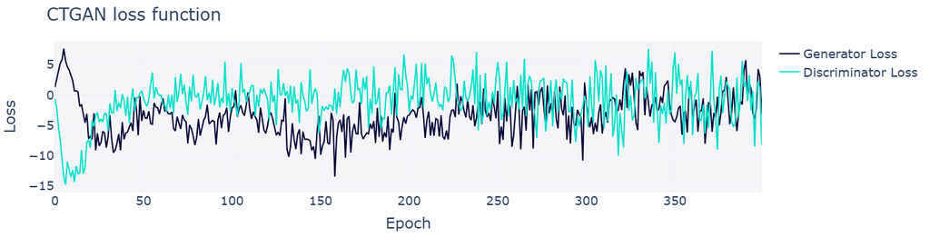

```
TRAINING LOSS CURVES: Tier: small IR: 009 Bootstrap: 00 Sample Size: 2234
```

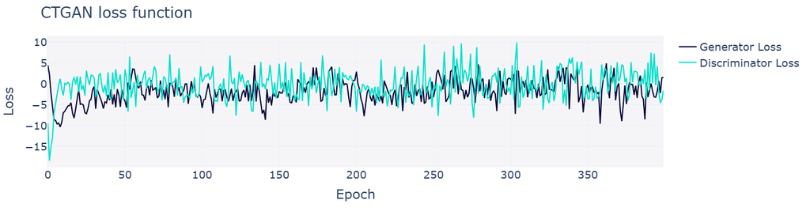

```
TRAINING LOSS CURVES: Tier: small IR: 003 Bootstrap: 00 Sample Size: 5586
```

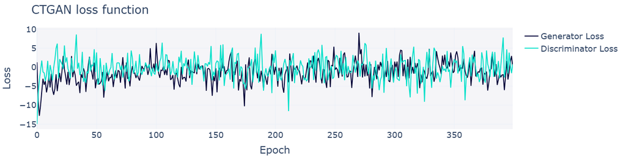

```
TRAINING LOSS CURVES: Tier: medium IR: 001 Bootstrap: 00 Sample Size: 22342
```

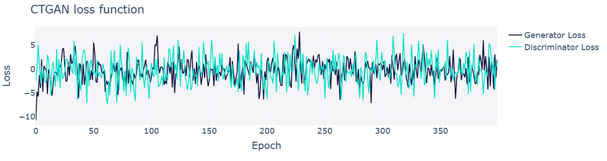

```python
import json
from sdv.utils import load_synthesizer

def loss_curves(tier, ir, bootstrap):
    '''
    Plot the training loss curves for the generator and the discriminator.
    '''
    # Load the model and parameters
    path = '..\\models\\ctgan\\'
    model_filename = f'synthesizer-{tier}-ir{ir:03d}-b{bootstrap:02d}.pkl'
    params_filename = f'synthesizer-{tier}-ir{ir:03d}-b{bootstrap:02d}.json'
    plot_filename = f'synthesizer-{tier}-ir{ir:03d}-b{bootstrap:02d}.png'
    with open(path + params_filename, 'r') as f:
        params = json.load(f)
    synthesizer = load_synthesizer(filepath = path + model_filename)

    # Display plot showing generator and discriminator loss by epoch
    print('\nTRAINING LOSS CURVES: Tier: {} IR: {:03d} Bootstrap: {:02d} Sample Size: {:d}'.format(
        tier, ir, bootstrap, params['n_samples']
    ))
    fig = synthesizer.get_loss_values_plot()
    fig.show()

# Call the loss curve function for each scenario
scenarios = [
    ('medium', 81, 0),
    ('small', 9, 0),
    ('small', 3, 0),
    ('medium', 1, 0)
]

for scenario in scenarios:
    loss_curves(*scenario)
```

## Detailed fidelity evaluation (final hyperparameters)

This section performs further detailed evaluation of fidelity and utility using only the selected best hyperparameters.

```python
# Define the scenarios for evaluation
#  (<tier>, <IR>, <bootstrap>, <sample size>)
scenarios = [
    ('medium', 81, 0, 545),
    ('small', 9, 0, 2234),
    ('small', 3, 0, 5586),
    ('medium', 1, 0, 22342)]
```

### Pair-wise correlation of numerical features

Calculate the correlation between numerical features for the real and synthetic data, then calcualte the difference between the correlations. Plot the three results using heatmaps.

```python
def pairwise_correlation(tier, ir, b, num_cols):
    '''
    Calculate the pair-wise correlation between numerical columns in the real and synthetic data.
    '''
    X_real, X_syn = hf_read_real_synthetic(tier, ir, b)
    # Filter the datasets on the numerical columns
    X_real_num = X_real[num_cols]
    X_syn_num = X_syn[num_cols]

    # Identify columns in the real of synthetic data with only one value. These will not have
    # meaningful correlations with other columns.
    one_val_real = [c for c in X_real_num.columns if X_real[c].nunique() == 1]
    one_val_syn = [c for c in X_syn_num.columns if X_syn[c].nunique() == 1]
    remove_cols = list(set(one_val_real) | set(one_val_syn))
    X_real_filtered = X_real_num.drop(columns=remove_cols)
    X_syn_filtered = X_syn_num.drop(columns=remove_cols)

    # Calculate the correlation matrices and the absolute difference
    real_corr = X_real_filtered.corr()
    syn_corr = X_syn_filtered.corr()
    corr_diff = (real_corr - syn_corr).abs()

    # Retrieve the values from the upper triangle of the matrix excluding the diagonal
    # then return the mean, standard deviation, and max of the differences
    tri = np.triu_indices(len(X_real_filtered.columns), k=1)
    vals = corr_diff.values[tri]
    corr_summary = {
        'mean_abs_diff': vals.mean().item(),
        'std_abs_diff': vals.std().item(),
        'max_abs_diff': vals.max().item()
    }

    return real_corr, syn_corr, corr_diff, corr_summary, remove_cols
```

```python
# Summary of correlation to test the function
for tier, ir, b, n in scenarios:
    (real_corr, syn_corr, corr_summary, corr_summary, remove_cols) = \
        pairwise_correlation(tier, ir, b, numerical_cols)
    print(tier, ir, b, n)
    print('Real columns:', len(real_corr), 'Synthetic columns:', len(syn_corr))
    print('Summary:', corr_summary)
    print('Removed columns:', remove_cols)
    print()
```

```
medium 81 0 545
Real columns: 68 Synthetic columns: 68
Summary: {'mean_abs_diff': 0.1776937501927982, 'std_abs_diff': 0.22860964961764899, 'max_abs_diff': 1.0648873897867046}
Removed columns: ['AMT_REQ_CREDIT_BUREAU_DAY', 'AMT_REQ_CREDIT_BUREAU_HOUR']

small 9 0 2234
Real columns: 70 Synthetic columns: 70
Summary: {'mean_abs_diff': 0.14879545220369744, 'std_abs_diff': 0.21518420636235588, 'max_abs_diff': 1.0243653064390297}
Removed columns: []

small 3 0 5586
Real columns: 70 Synthetic columns: 70
Summary: {'mean_abs_diff': 0.09289998687628262, 'std_abs_diff': 0.14046865554130797, 'max_abs_diff': 0.9828992968265016}
Removed columns: []

medium 1 0 22342
Real columns: 68 Synthetic columns: 68
Summary: {'mean_abs_diff': 0.08439912969642423, 'std_abs_diff': 0.11834306478177267, 'max_abs_diff': 0.9277418873235705}
Removed columns: ['AMT_REQ_CREDIT_BUREAU_DAY', 'AMT_REQ_CREDIT_BUREAU_HOUR']
```

```python
from tabulate import tabulate

# Calculate the KS statistic for selected scenarios
results = []
correlations = []
for tier, ir, b, n in scenarios:
    scenario = f'{tier}-{ir:d}-{bootstrap:d}-{n:d}'
    (real_corr,
     syn_corr,
     corr_diff,
     corr_summary,
     remove_cols) = pairwise_correlation(tier, ir, b, numerical_cols)

    # Create a list of summary results for tabulating.
    results.append([
        #f'{tier} {ir:d} {bootstrap:d} {n:d}',
        scenario,
        corr_summary['mean_abs_diff'],
        corr_summary['std_abs_diff'],
        corr_summary['max_abs_diff']])

    # Create a list of correlations for visualisation
    correlations.append((scenario, n, real_corr, syn_corr, corr_diff))

# Tabulate the results
result_headers = ['Scenario', 'mean_abs_diff', 'std_abs_diff', 'max_abs_diff']

print('\nPAIR-WISE CORRELATION DIFFERENCE OF NUMERICAL FEATURES\n')
print(tabulate(
        results,
        headers=result_headers,
        floatfmt=".3f",
        tablefmt="github"
))
print()
```

```
PAIR-WISE CORRELATION DIFFERENCE OF NUMERICAL FEATURES

| Scenario         |   mean_abs_diff |   std_abs_diff |   max_abs_diff |
|------------------|-----------------|----------------|----------------|
| medium-81-0-545  |           0.178 |          0.229 |          1.065 |
| small-9-0-2234   |           0.149 |          0.215 |          1.024 |
| small-3-0-5586   |           0.093 |          0.140 |          0.983 |
| medium-1-0-22342 |           0.084 |          0.118 |          0.928 |
```

### Correlation Heatmap

Plot the correlation matrices for the four evaluation scenarios as heatmaps.

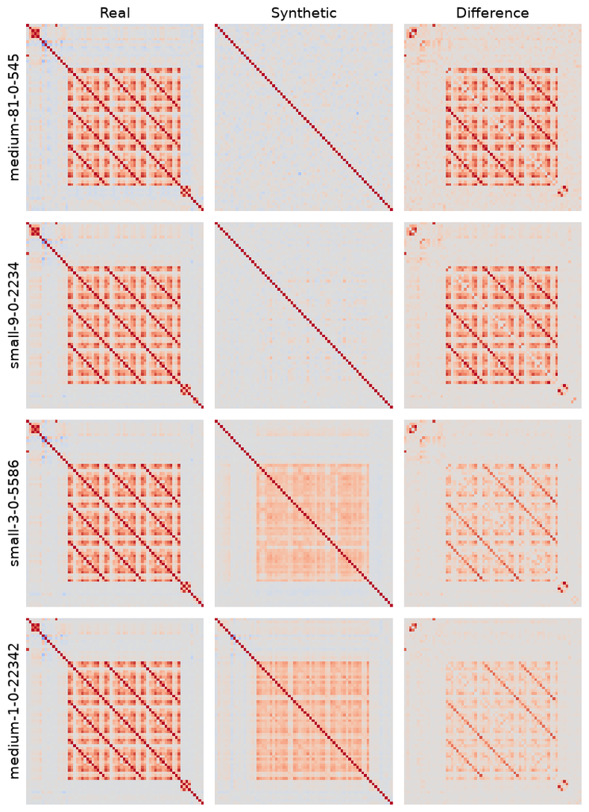

```python
import seaborn as sns
import matplotlib.pyplot as plt

fig, axes = plt.subplots(4, 3, figsize=(8, 11), sharex=True, sharey=True)

titles = ('Real', 'Synthetic', 'Difference')
text_font = {'fontsize': 14}

# Iterate through the correlations for the four scenarios
for r, corr in enumerate(correlations):
    # Read the scenario label and the matrics from the correlation results
    scenario = corr[0]
    maps = corr[2:]

    # Plot the real, synthetic, then difference in each column
    for c in range(3):
        ax = axes[r, c]
        sns.heatmap(
            maps[c],
            cmap="coolwarm",
            vmin=-1, vmax=1,
            ax=ax,
            cbar=False
        )
        # Remove the tick labels
        ax.set_xticklabels([])
        ax.set_yticklabels([])
        ax.set_xticks([])
        ax.set_yticks([])

        # Set the title on the first row
        if r == 0:
            ax.set_title(titles[c], **text_font)

        # Set the row heading on the first column
        if c == 0:
            ax.set_ylabel(scenario, rotation=90, ha='center', va='bottom', **text_font)

# Disaplay and save the plot
plt.tight_layout()
plt.savefig("..\\heatmap_real.png", dpi=300, bbox_inches="tight")
plt.show()
```

**Observations**  
The 545 and 2234 sample scenario are unable to learn the correlations between numerical columns, which become apparent only at sample size 5586 and strength slightly at 22342.

### KS Statistic

Calculate the Kolmogorov-Smirnov statistic for each column, which compares the real and synthetic distributions.

```python
from scipy.stats import ks_2samp

def ks_statistic(tier, ir, b, num_cols):
    '''
    Calculate the Kolmogorov-Smirnov statistic for each column.
    '''
    X_real, X_syn = hf_read_real_synthetic(tier, ir, b)
    X_real_num = X_real[num_cols]
    X_syn_num = X_syn[num_cols]

    # Calculate the KS statistic for each column
    ks_vals = {}
    for col in num_cols:
        ks_stat, _ = ks_2samp(X_real_num[col], X_syn_num[col])
        ks_vals[col] = ks_stat.item()

    # Sort the results to help with reporting
    ks_vals_sorted = dict(sorted(ks_vals.items(), key=lambda x: x[1]))

    # Convert the results to a np vector and calculate summary statistics
    ks_array = np.array(list(ks_vals.values()))
    ks_summary = {
        'mean_ks': ks_array.mean().item(),
        'std_ks': ks_array.std().item(),
        'max_ks': ks_array.max().item()
    }

    return ks_vals_sorted, ks_summary
```

```python
# Calculate KS statistic for one representative scenario

# Calculate KS for a selection of scenarios
ks_val_results = {}
ks_summary_results = []
for s in scenarios:
    tier, ir, b, n = s
    ks_vals, ks_summary = ks_statistic(tier, ir, b, numerical_cols)
    ks_val_results[s] = ks_vals
    ks_summary_results.append([
        s,
        ks_summary['mean_ks'],
        ks_summary['std_ks'],
        ks_summary['max_ks']
    ])

# Tabulate the summary
ks_headers = ['Scenario', 'Mean KS', 'STD KS', 'Max KS']
print('\nKOLMOGOROV-SMIRNOV STATISTIC SUMMARY\n')
print(tabulate(
        ks_summary_results,
        headers=ks_headers,
        floatfmt='.3f',
        tablefmt="github"
))
print()

# Tabulate the detailed results - Each scenario may have sorted columns differently, iterate
# the columns in the largest scenario and show the values for the other scenarios.
ks_detail = []
for col in ks_val_results[scenarios[3]].keys():     # Use columns from the biggest sample
    #s = (tier, ir, b)
    vals = [ks_val_results[s][col] for s in scenarios]  # Read ks from the dict or dicts
    vals = [col] + vals                                 # Prepend the scenario label
    ks_detail.append(vals)

ks_detail_headers = ['Column'] + [f'{s[0]}, {s[1]}\n{s[3]:,}' for s in scenarios]

print(tabulate(
    ks_detail,
    #headers=scenarios,                                  # Use the scenario list as headers
    headers=ks_detail_headers,
    floatfmt='.3f',
    tablefmt='github'
))
```

```
KOLMOGOROV-SMIRNOV STATISTIC SUMMARY

| Scenario                |   Mean KS |   STD KS |   Max KS |
|-------------------------|-----------|----------|----------|
| ('medium', 81, 0, 545)  |     0.274 |    0.160 |    0.543 |
| ('small', 9, 0, 2234)   |     0.295 |    0.186 |    0.673 |
| ('small', 3, 0, 5586)   |     0.293 |    0.188 |    0.653 |
| ('medium', 1, 0, 22342) |     0.308 |    0.192 |    0.628 |

| Column                       |   medium, 81 |   small, 9 |   small, 3 |   medium, 1 |
|                              |          545 |      2,234 |      5,586 |      22,342 |
|------------------------------|--------------|------------|------------|-------------|
| AMT_REQ_CREDIT_BUREAU_WEEK   |        0.007 |      0.006 |      0.022 |       0.004 |
| AMT_REQ_CREDIT_BUREAU_HOUR   |        0.002 |      0.003 |      0.002 |       0.005 |
| AMT_REQ_CREDIT_BUREAU_DAY    |        0.006 |      0.004 |      0.001 |       0.006 |
| DEF_60_CNT_SOCIAL_CIRCLE     |        0.011 |      0.012 |      0.015 |       0.008 |
| ELEVATORS_MEDI               |        0.106 |      0.046 |      0.051 |       0.014 |
| OWN_CAR_AGE                  |        0.218 |      0.050 |      0.020 |       0.020 |
| AMT_REQ_CREDIT_BUREAU_MON    |        0.083 |      0.059 |      0.003 |       0.021 |
| OBS_30_CNT_SOCIAL_CIRCLE     |        0.128 |      0.040 |      0.097 |       0.031 |
| OBS_60_CNT_SOCIAL_CIRCLE     |        0.090 |      0.155 |      0.030 |       0.032 |
| HOUR_APPR_PROCESS_START      |        0.066 |      0.097 |      0.072 |       0.046 |
| CNT_CHILDREN                 |        0.075 |      0.050 |      0.025 |       0.050 |
| DEF_30_CNT_SOCIAL_CIRCLE     |        0.022 |      0.021 |      0.074 |       0.053 |
| DAYS_BIRTH                   |        0.127 |      0.092 |      0.038 |       0.056 |
| AMT_REQ_CREDIT_BUREAU_QRT    |        0.037 |      0.045 |      0.011 |       0.060 |
| CNT_FAM_MEMBERS              |        0.070 |      0.057 |      0.095 |       0.062 |
| AMT_CREDIT                   |        0.088 |      0.148 |      0.092 |       0.075 |
| DAYS_ID_PUBLISH              |        0.048 |      0.106 |      0.119 |       0.079 |
| DAYS_LAST_PHONE_CHANGE       |        0.105 |      0.088 |      0.080 |       0.092 |
| EXT_SOURCE_2                 |        0.077 |      0.039 |      0.121 |       0.100 |
| AMT_GOODS_PRICE              |        0.167 |      0.152 |      0.078 |       0.104 |
| AMT_ANNUITY                  |        0.040 |      0.086 |      0.168 |       0.114 |
| REGION_POPULATION_RELATIVE   |        0.099 |      0.107 |      0.099 |       0.142 |
| AMT_REQ_CREDIT_BUREAU_YEAR   |        0.029 |      0.043 |      0.021 |       0.149 |
| DAYS_REGISTRATION            |        0.075 |      0.111 |      0.110 |       0.158 |
| EXT_SOURCE_3                 |        0.145 |      0.149 |      0.239 |       0.218 |
| YEARS_BEGINEXPLUATATION_AVG  |        0.420 |      0.281 |      0.418 |       0.280 |
| AMT_INCOME_TOTAL             |        0.116 |      0.168 |      0.064 |       0.294 |
| NONLIVINGAREA_MODE           |        0.387 |      0.509 |      0.449 |       0.312 |
```

[output cut: 27 more lines]

```
| ENTRANCES_AVG                |        0.387 |      0.453 |      0.450 |       0.474 |
| LANDAREA_MEDI                |        0.428 |      0.348 |      0.433 |       0.475 |
| LIVINGAREA_MEDI              |        0.339 |      0.417 |      0.341 |       0.475 |
| FLOORSMIN_AVG                |        0.411 |      0.461 |      0.424 |       0.475 |
| NONLIVINGAREA_AVG            |        0.310 |      0.358 |      0.479 |       0.479 |
| ENTRANCES_MEDI               |        0.420 |      0.326 |      0.388 |       0.483 |
| COMMONAREA_MODE              |        0.361 |      0.482 |      0.437 |       0.504 |
| COMMONAREA_AVG               |        0.367 |      0.479 |      0.506 |       0.505 |
| LANDAREA_MODE                |        0.371 |      0.403 |      0.338 |       0.506 |
| FLOORSMIN_MODE               |        0.459 |      0.533 |      0.504 |       0.518 |
| NONLIVINGAPARTMENTS_MEDI     |        0.503 |      0.353 |      0.653 |       0.547 |
| NONLIVINGAREA_MEDI           |        0.330 |      0.310 |      0.394 |       0.555 |
| LIVINGAPARTMENTS_MODE        |        0.470 |      0.425 |      0.429 |       0.586 |
| YEARS_BUILD_MEDI             |        0.380 |      0.542 |      0.401 |       0.603 |
| ELEVATORS_AVG                |        0.543 |      0.673 |      0.351 |       0.628 |
```

## Detailed utility evaluation

### TRTR vs TSTR

To test the utility of the synthetic data use train-real-test-real versus train-synthetic-test-real (TRTR vs TSTR). This evaluation compares the performance of the synthetic data on a learning task with the real data.

```python
from xgboost import XGBClassifier

# Create a single XGBoost classifier
def xgb_classifier():
    '''
    Create an xgb classifier using representative hyperparameters selected from the full grid.
    medium, IR 1
    '''
    fixed_params = {
        # Fixed
        'tree_method': 'hist',
        'objective': 'binary:logistic',
        'enable_categorical': True,
        'eval_metric': ['auc', 'logloss', 'aucpr'],  # List aucpr last to determine early stopping
        'nthread': 4,
        'early_stopping_rounds': 100,
        'verbosity': 0
    }
    # Tuned
    tuned_params = {
        'n_estimators': 1200,
        'colsample_bytree': 0.6,
        'learning_rate': 0.1,
        'reg_alpha': 1.0,
        'reg_lambda': 2.0,
        'subsample': 0.8,
        'scale_pos_weight': 0.5,
        'min_child_weight': 5,
        'max_depth': 8,
        'gamma': 5
    }
    params = fixed_params | tuned_params

    return XGBClassifier(**params)
```

```python
# TEST
if False:
    clf = xgb_classifier()
    print(clf)
```

```python
from sklearn.model_selection import train_test_split
from sklearn.metrics import precision_score, recall_score, f1_score

def train_xgb(X_train, y_train, X_test, y_test):
    '''
    Train an XGB model
    '''
    clf = xgb_classifier()
    clf.fit(X_train, y_train, eval_set=[(X_test, y_test)], verbose=False)

    # Read the results obtained for the validation fold from the trained model
    results = {}
    metric_results = clf.evals_result()['validation_0']
    results['n_estimators'] = clf.n_estimators
    results['early_stopping_rounds'] = clf.early_stopping_rounds

    # Read the best iteration then read the results for that iteration
    results['best_iteration'] = clf.best_iteration
    results['pr_auc'] = metric_results['aucpr'][results['best_iteration']]
    results['roc_auc'] = metric_results['auc'][results['best_iteration']]
    results['log_loss'] = metric_results['logloss'][results['best_iteration']]

    # Calculate threshold dependent metrics. Assume 0.5 for balanced dataset
    y_prob = clf.predict_proba(X_test)[:, 1]
    threshold = 0.5
    y_pred = (y_prob >= threshold).astype(int)
    results['max_prob'] = y_prob.max().item()
    results['precision'] = precision_score(y_test, y_pred)
    results['recall'] = recall_score(y_test, y_pred)
    results['f1_score'] = f1_score(y_test, y_pred)

    # Tune the threshold to optimise F1
    best_threshold = None
    best_f1_score = 0
    best_precision = 0
    best_recall = 0
    for t in np.linspace(0.0, 1.0, 1001):
        y_pred = (y_prob >= t).astype(int)
        f1 = f1_score(y_test, y_pred)
        if f1 > best_f1_score:
            best_threshold = t
            best_precision = precision_score(y_test, y_pred)
            best_recall = recall_score(y_test, y_pred)
            best_f1_score = f1
    results['best_threshold'] = best_threshold.item()
    results['precision_tuned'] = best_precision
    results['recall_tuned'] = best_recall
    results['f1_score_tuned'] = best_f1_score

    return results
```

```python
def trtr_tstr(tier, ir, b):
    '''
    Train models using real and real-synthetic dataset and evaluate against the real dataset.
    '''
    # Read the real data and create a train-test split
    X_real, y_real = hf_read_real_data(tier, ir, b)

    X_train, X_test, y_train, y_test = train_test_split(
        X_real, y_real, test_size=0.2, random_state=42, stratify=y_real)

    # Replace the minority class data with the synthetic data. Select and 80% sample to match
    # the size of the training set, and maintain an IR of 1
    X_train_maj = X_train[y_train==0]
    y_train_maj = y_train[y_train==0]

    # Read the synthetic data
    X_syn, y_syn = hf_read_synthetic_data(tier, ir, b, 100)
    n_pos = len(X_syn)
    n_neg = len(X_real) - n_pos

    # Align the categories for categorical columns with the training set categories
    for col in X_real.columns:
        if X_real[col].dtype == 'category':
            X_syn[col] = X_syn[col].cat.set_categories(
                X_real[col].cat.categories,
                ordered=X_real[col].cat.ordered)

    # Downsample the synthetic data to match the size of the training set
    X_train_syn, _, y_train_syn, _ = train_test_split(
        X_syn, y_syn, train_size=0.8, random_state=42)

    # Concatenate the real majority and synthetic minority datasets
    X_train_hybrid = pd.concat([X_train_maj, X_train_syn])
    y_train_hybrid = pd.concat([y_train_maj, y_train_syn])

    # Test the real and synthetic dataset against the real test set
    real_results = train_xgb(X_train, y_train, X_test, y_test)
    synthetic_results = train_xgb(X_train_hybrid, y_train_hybrid, X_test, y_test)

    return n_neg, n_pos, real_results, synthetic_results
```

```python
from pathlib import Path

# Calculate TRTR_TSTR for selected scenarios

# Iterate through the sample sizes
results = {}
for tier, ir, b, n in scenarios:
    print('Calculating TRTR-TSTR for', tier, ir, b)

    # Call the training function to evaluate the real and synthetic datasets
    n_neg, n_pos, trtr_results, tstr_results = trtr_tstr(tier, ir, b)

    # Save the results for all samples sizes in a dict
    s_key = f'{tier}-ir{ir:03d}'
    results[s_key] = {'n_neg': n_neg,
                      'n_pos': n_pos,
                      'trtr': trtr_results,
                      'tstr': tstr_results}

# Save the dict of all results to a JSON file
filepath = Path(f'..\\models\\ctgan\\results-b{b:02d}')
filename = f'trtr-tstr-results.json'
print('Saving results to', filepath / filename)
with open(filepath / filename, 'w') as f:
    json.dump(results, f, indent=2)

print('\n-- Complete --')
```

```
Calculating TRTR-TSTR for medium 81 0
```

```
Calculating TRTR-TSTR for small 9 0
```

```
Calculating TRTR-TSTR for small 3 0
```

```
Calculating TRTR-TSTR for medium 1 0
```

```
Saving results to ..\models\ctgan\results-b00\trtr-tstr-results.json

-- Complete --
```

```python
from pathlib import Path
from tabulate import tabulate, SEPARATING_LINE

# Read the trtr-tstr results
root = filepath = Path('..\\models\\ctgan\\results-b00\\')
filename = f'trtr-tstr-results.json'
with open(root / filename, 'r') as f:
    all_results = json.load(f)

# Tabulate the results for each scenario
print('\nTRTR VERSUS TSTR EVALUATION METRIC - THRESHOLD DEPENDENT & THRESHOLD INDEPENDENT\n')
results_header = ['Scenario', 'N_neg', 'N_pos', 'Metric', 'TRTR', 'TSTR']     # Header row

# Create a list-of-lists of results for TRTR and TSTR
results_table = []
for scenario, results in all_results.items():
    # Create a results table
    for (r, rv), (s, sv) in zip(results['trtr'].items(), results['tstr'].items()):
        results_table.append([scenario, results['n_neg'], results['n_pos'], r, rv, sv])
    results_table.append(SEPARATING_LINE)

# Print the table
print(tabulate(
        results_table,
        headers=results_header,
        floatfmt=".3f",
        tablefmt="github"
))
print()
```

```
TRTR VERSUS TSTR EVALUATION METRIC - THRESHOLD DEPENDENT & THRESHOLD INDEPENDENT

| Scenario     |   N_neg |   N_pos | Metric                |     TRTR |     TSTR |
|--------------|---------|---------|-----------------------|----------|----------|
| medium-ir081 |   44139 |     545 | n_estimators          | 1200.000 | 1200.000 |
| medium-ir081 |   44139 |     545 | early_stopping_rounds |  100.000 |  100.000 |
| medium-ir081 |   44139 |     545 | best_iteration        |   63.000 |    0.000 |
| medium-ir081 |   44139 |     545 | pr_auc                |    0.034 |    0.012 |
| medium-ir081 |   44139 |     545 | roc_auc               |    0.693 |    0.496 |
| medium-ir081 |   44139 |     545 | log_loss              |    0.065 |    0.142 |
| medium-ir081 |   44139 |     545 | max_prob              |    0.050 |    0.162 |
| medium-ir081 |   44139 |     545 | precision             |    0.000 |    0.000 |
| medium-ir081 |   44139 |     545 | recall                |    0.000 |    0.000 |
| medium-ir081 |   44139 |     545 | f1_score              |    0.000 |    0.000 |
| medium-ir081 |   44139 |     545 | best_threshold        |    0.017 |    0.000 |
| medium-ir081 |   44139 |     545 | precision_tuned       |    0.065 |    0.012 |
| medium-ir081 |   44139 |     545 | recall_tuned          |    0.165 |    1.000 |
| medium-ir081 |   44139 |     545 | f1_score_tuned        |    0.094 |    0.024 |
|--------------|---------|---------|-----------------------|----------|----------|
| small-ir009  |   20108 |    2234 | n_estimators          | 1200.000 | 1200.000 |
| small-ir009  |   20108 |    2234 | early_stopping_rounds |  100.000 |  100.000 |
| small-ir009  |   20108 |    2234 | best_iteration        |   23.000 |    0.000 |
| small-ir009  |   20108 |    2234 | pr_auc                |    0.240 |    0.097 |
| small-ir009  |   20108 |    2234 | roc_auc               |    0.715 |    0.494 |
| small-ir009  |   20108 |    2234 | log_loss              |    0.311 |    0.330 |
| small-ir009  |   20108 |    2234 | max_prob              |    0.315 |    0.245 |
| small-ir009  |   20108 |    2234 | precision             |    0.000 |    0.000 |
| small-ir009  |   20108 |    2234 | recall                |    0.000 |    0.000 |
| small-ir009  |   20108 |    2234 | f1_score              |    0.000 |    0.000 |
| small-ir009  |   20108 |    2234 | best_threshold        |    0.075 |    0.000 |
| small-ir009  |   20108 |    2234 | precision_tuned       |    0.215 |    0.100 |
| small-ir009  |   20108 |    2234 | recall_tuned          |    0.506 |    1.000 |
| small-ir009  |   20108 |    2234 | f1_score_tuned        |    0.302 |    0.182 |
|--------------|---------|---------|-----------------------|----------|----------|
| small-ir003  |   16756 |    5586 | n_estimators          | 1200.000 | 1200.000 |
| small-ir003  |   16756 |    5586 | early_stopping_rounds |  100.000 |  100.000 |
| small-ir003  |   16756 |    5586 | best_iteration        |   53.000 |  112.000 |
| small-ir003  |   16756 |    5586 | pr_auc                |    0.487 |    0.249 |
| small-ir003  |   16756 |    5586 | roc_auc               |    0.743 |    0.512 |
| small-ir003  |   16756 |    5586 | log_loss              |    0.525 |    1.590 |
```

[output cut: 9 more lines]

```
| medium-ir001 |   22342 |   22342 | n_estimators          | 1200.000 | 1200.000 |
| medium-ir001 |   22342 |   22342 | early_stopping_rounds |  100.000 |  100.000 |
| medium-ir001 |   22342 |   22342 | best_iteration        |  179.000 |    1.000 |
| medium-ir001 |   22342 |   22342 | pr_auc                |    0.741 |    0.489 |
| medium-ir001 |   22342 |   22342 | roc_auc               |    0.751 |    0.496 |
| medium-ir001 |   22342 |   22342 | log_loss              |    0.637 |    0.802 |
| medium-ir001 |   22342 |   22342 | max_prob              |    0.916 |    0.458 |
| medium-ir001 |   22342 |   22342 | precision             |    0.771 |    0.000 |
| medium-ir001 |   22342 |   22342 | recall                |    0.422 |    0.000 |
| medium-ir001 |   22342 |   22342 | f1_score              |    0.546 |    0.000 |
| medium-ir001 |   22342 |   22342 | best_threshold        |    0.215 |    0.000 |
| medium-ir001 |   22342 |   22342 | precision_tuned       |    0.616 |    0.500 |
| medium-ir001 |   22342 |   22342 | recall_tuned          |    0.861 |    1.000 |
| medium-ir001 |   22342 |   22342 | f1_score_tuned        |    0.718 |    0.667 |
|--------------|---------|---------|-----------------------|----------|----------|
```

-- End of notebook --